# Práctica 1 - Aprendizaje supervisado

Aprendizaje Computacional, Grado en Ingeniería Informática. Universidad de Murcia. Nicolás Enrique Linares La Barba y Rubén Marín García.

12/11/2019

# 1 Dominio de la práctica

> Se trata de una encuesta realizada tras las elecciones Británicas de 2001 para determinar cómo de influyente era la actitud del electorado hacia una apertura a la integración con Europa junto con el conocimiento que se tenía de cada uno de los partidos políticos que participaron en dichas elecciones.

> Nos vamos a hacer una pregunta central sobre la que ha de girar todo el análisis: **¿en qué medida podemos predecir el voto de un individuo a partir de hacerle responder a cuestiones indirectas sobre el asunto principal?** Cuestiones secundarias que convendría analizar son ¿es innecesaria alguna de las preguntas de nuestra encuesta? ¿qué preguntas son más decisivas a la hora de realizar la predicción?

# 2 Análisis individual de las variables

Instalamos el paquete con el que vamos a trabajar y cargamos la librería.

```r
#install.packages("carData")

library(carData)
data(BEPS)
str(BEPS)
```

```
## 'data.frame':    1525 obs. of  10 variables:
##  $ vote                   : Factor w/ 3 levels "Conservative",..: 3 2 2 2 2 2 3 2 2 2 ...
##  $ age                    : int  43 36 35 24 41 47 57 77 39 70 ...
##  $ economic.cond.national : int  3 4 4 4 2 3 2 3 3 3 ...
##  $ economic.cond.household: int  3 4 4 2 2 4 2 4 3 2 ...
##  $ Blair                  : int  4 4 5 2 1 4 4 4 4 5 ...
##  $ Hague                  : int  1 4 2 1 1 4 4 1 4 1 ...
##  $ Kennedy                : int  4 4 3 3 4 2 2 4 4 1 ...
##  $ Europe                 : int  2 5 3 4 6 4 11 1 11 11 ...
##  $ political.knowledge    : int  2 2 2 0 2 2 2 0 0 2 ...
##  $ gender                 : Factor w/ 2 levels "female","male": 1 2 2 1 2 2 2 2 1 2 ...
```

> Podemos observar que tenemos un frame de datos compuesto por 2 factores: el factor *vote* con 3 niveles que indica el voto del encuestado (conservadores, laboristas y demócratas, respectivamente) y el factor *gender* que indica el género del encuestado; y otros valores numéricos como la edad, la percepción de la economía nacional y doméstica, además de la evaluación que le dan a los 3 líderes políticos: *Blair* para el bando laborista, *Hague* para el bando conservador y *Kennedy* para el bando demócrata.

> **Estamos ante un problema de clasificación**, ya que se trata de buscar aquellos indicios que nos permitan categorizar los datos en cada líder político.

Realizamos un resumen estadístico para tener una idea superficial de nuestros datos y emplearemos la representación basada en histogramas y diagramas de barras para observar las variables de forma convincente.

```r
summary(BEPS)
```

```
##                vote          age        economic.cond.national
##  Conservative    :462   Min.   :24.00   Min.   :1.000
##  Labour          :720   1st Qu.:41.00   1st Qu.:3.000
##  Liberal Democrat:343   Median :53.00   Median :3.000
##                         Mean   :54.18   Mean   :3.246
##                         3rd Qu.:67.00   3rd Qu.:4.000
##                         Max.   :93.00   Max.   :5.000
##  economic.cond.household     Blair           Hague          Kennedy
##  Min.   :1.00            Min.   :1.000   Min.   :1.000   Min.   :1.000
##  1st Qu.:3.00            1st Qu.:2.000   1st Qu.:2.000   1st Qu.:2.000
##  Median :3.00            Median :4.000   Median :2.000   Median :3.000
##  Mean   :3.14            Mean   :3.334   Mean   :2.747   Mean   :3.135
##  3rd Qu.:4.00            3rd Qu.:4.000   3rd Qu.:4.000   3rd Qu.:4.000
##  Max.   :5.00            Max.   :5.000   Max.   :5.000   Max.   :5.000
##      Europe       political.knowledge    gender
##  Min.   : 1.000   Min.   :0.000       female:812
##  1st Qu.: 4.000   1st Qu.:0.000       male  :713
##  Median : 6.000   Median :2.000
##  Mean   : 6.729   Mean   :1.542
##  3rd Qu.:10.000   3rd Qu.:2.000
##  Max.   :11.000   Max.   :3.000
```

## 2.1 Variable Age

```r
# Resumen estadístico
summary(BEPS$age)
```

```
##    Min. 1st Qu.  Median    Mean 3rd Qu.    Max.
##   24.00   41.00   53.00   54.18   67.00   93.00
```

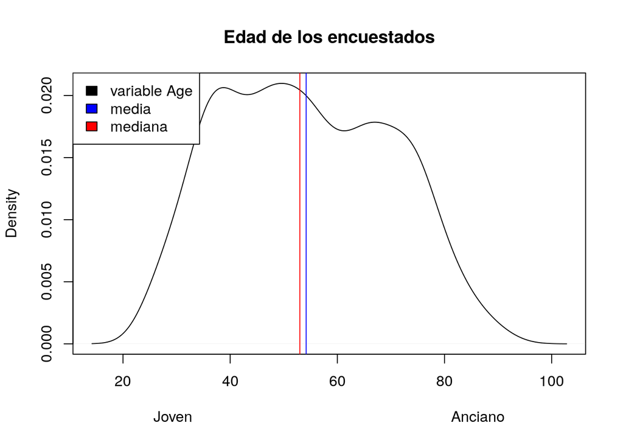

```r
plot(density(BEPS$age, na.rm = T), main = "Edad de los encuestados", xlab = "Joven                                                              Anciano")
# Marca el valor de la media con una línea azul
abline(v=mean(BEPS$age), col="blue")
# Marca el valor de la mediana con una línea roja
abline(v=median(BEPS$age), col="red")
legend("topleft", fill=c("black","blue","red"),legend = c("variable Age","media","mediana"))
```

> Podemos observar que el 25% de los encuestados tienen una edad inferior a 41 años (primer cuartil), que la media de edad de los encuestados está en 54.18 y la mediana en 53 años, lo que a priori, podría ser un indicativo de que entre lo encuestados hay un mayor número de personas mayores de 53 años que menores de 53 años. También podemos observar que un 75% de los encuestados (tercer cuartil) tienen una edad inferior a 67 años y que el 25% restante son mayores de esa edad.

## 2.2 Variable Economic.cond.national

```r
# Resumen estadístico
summary(BEPS$economic.cond.national)
```

```
##    Min. 1st Qu.  Median    Mean 3rd Qu.    Max.
##   1.000   3.000   3.000   3.246   4.000   5.000
```

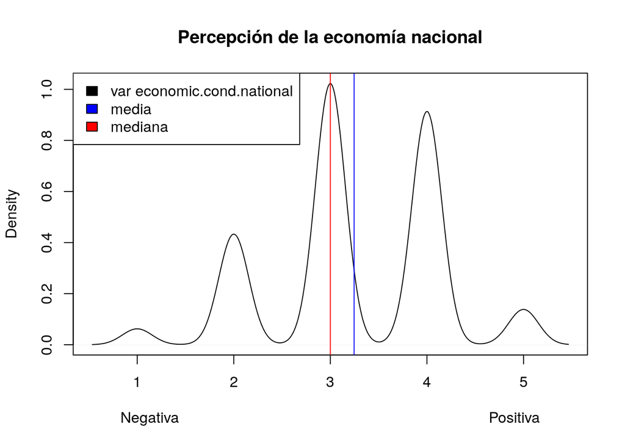

```r
# Graficamos los datos en un histograma
plot(density(BEPS$economic.cond.national, na.rm = T),
     main = "Percepción de la economía nacional",
     xlab = "Negativa                                                                          Positiva")
# Marca el valor de la media con una línea azul
abline(v=mean(BEPS$economic.cond.national), col="blue")
# Marca el valor de la mediana con una línea roja
abline(v=median(BEPS$economic.cond.national), col="red")
legend("topleft", fill=c("black","blue","red"),legend = c("var economic.cond.national","media","mediana"))
```

> En general la media indica que los encuestados tienen una percepción positiva de la economía nacional. La mediana se encuentra desplazada a la izquierda de la media con un valor de 3, con lo que a priori, solo con este summary, podriamos deducir que hay más puntuaciones por encima del valor 3, que por debajo.

En el siguiente gráfico de barras se puede observar claramente el número de encuestados por cada valor de evaluación.

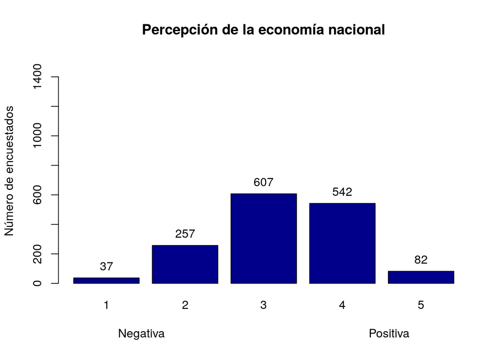

```r
# Diagrama de barras con el número de encuestados por cada valor de evaluación
tabla <- table(BEPS$economic.cond.national)
posbar <- barplot(tabla,
                  col = "darkblue",
                  ylab = "Número de encuestados",
                  xlab = "Negativa                                                             Positiva",
                  ylim=c(0, sum(tabla)),
                  main="Percepción de la economía nacional")
text(posbar, tabla + 80,labels=as.character(tabla))
```

> Efectivamente, como habíamos deducido, podemos ver que hay un mayor número de encuestados con una percepción positiva de la economía nacional que con una percepción negativa. En concreto, 624 de 1525 encuestados tienen una percepción positiva de la economía nacional, es decir, 40.92 % de los encuestados.

## 2.3 Variable Economic.cond.household

```r
# Resumen estadístico
summary(BEPS$economic.cond.household)
```

```
##    Min. 1st Qu.  Median    Mean 3rd Qu.    Max.
##    1.00    3.00    3.00    3.14    4.00    5.00
```

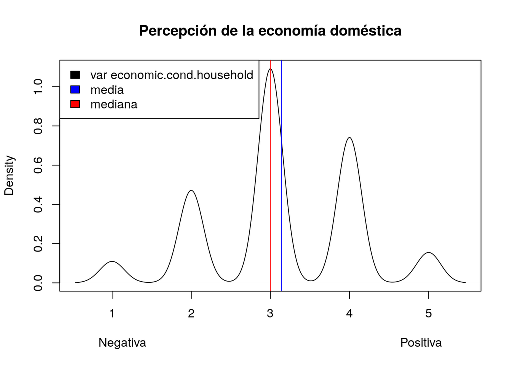

```r
# Graficamos los datos en un histograma
plot(density(BEPS$economic.cond.household, na.rm = T),
     main = "Percepción de la economía doméstica",
     xlab = "Negativa                                                                          Positiva")
# Marca el valor de la media con una línea azul
abline(v=mean(BEPS$economic.cond.household), col="blue")
# Marca el valor de la mediana con una línea roja
abline(v=median(BEPS$economic.cond.household), col="red")
legend("topleft", fill=c("black","blue","red"),legend = c("var economic.cond.household","media","mediana"))
```

> En general la media indica que los encuestados tienen una percepción positiva de la economía doméstica. La mediana se encuentra desplazada a la izquierda de la media con un valor de 3, con lo que a priori, solo con este summary, podríamos deducir que hay más puntuaciones por encima del valor 3, que por debajo.

En el siguiente gráfico de barras se puede observar claramente el número de encuestados por cada valor de evaluación.

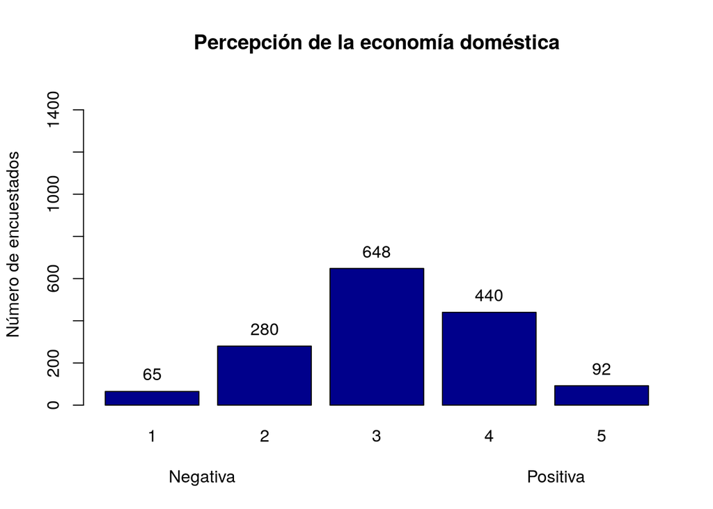

```r
# Diagrama de barras con el número de encuestados por cada valor de evaluación
tabla <- table(BEPS$economic.cond.household)
posbar <- barplot(tabla,
                  col = "darkblue",
                  ylab = "Número de encuestados",
                  xlab = "Negativa                                                             Positiva",
                  ylim=c(0, sum(tabla)),
                  main="Percepción de la economía doméstica")
text(posbar, tabla + 80,labels=as.character(tabla))
```

> Se observa en el diagrama de barras anterior que hay un mayor número de encuestados con una percepción positiva de la economía doméstica que con una percepción negativa, tomando como negativa por debajo de 3. En concreto, 1180 de 1525 encuestados tienen una percepción positiva, es decir, 77.38 % de los encuestados.

## 2.4 Variables Blair, Hague y Kennedy

> La evaluación de estos líderes políticos se ha hecho entre los valores 1 y 5, como indican el máximo y el mínimo, asumiendo que cuanto más alto el valor más positiva es la valoración de los encuestados.

### 2.4.1 Blair

```r
# Resumen estadístico
summary(BEPS$Blair)
```

```
##    Min. 1st Qu.  Median    Mean 3rd Qu.    Max.
##   1.000   2.000   4.000   3.334   4.000   5.000
```

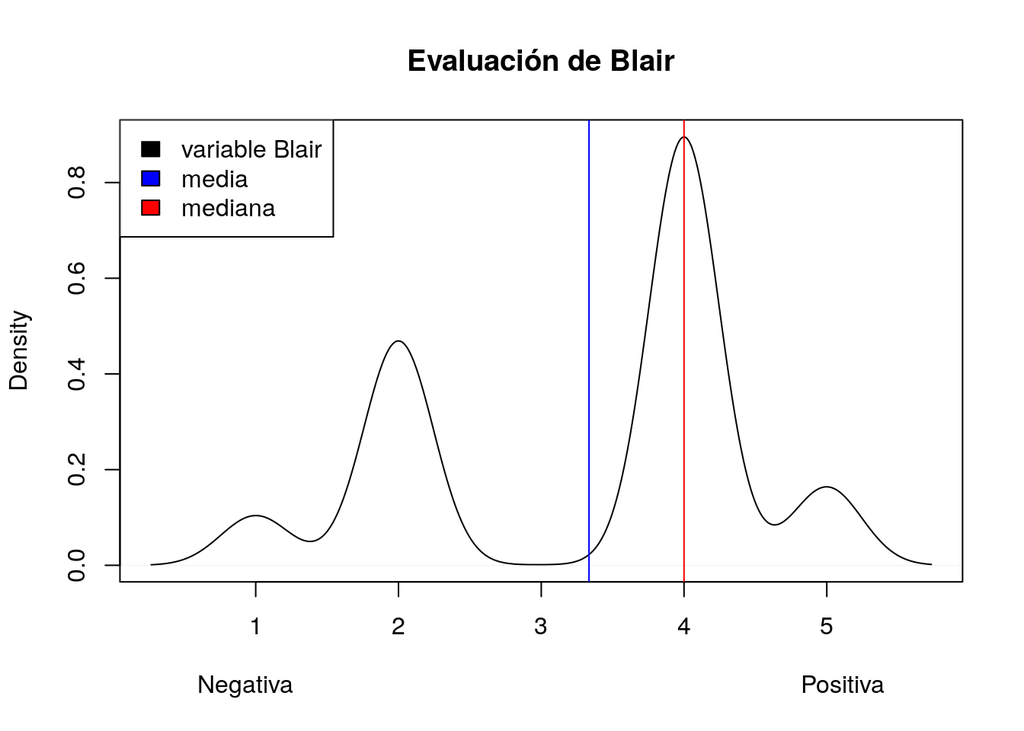

```r
# Graficamos los datos en un histograma
plot(density(BEPS$Blair, na.rm = T),
     main = "Evaluación de Blair",
     xlab = "Negativa                                                                          Positiva")
# Marca el valor de la media con una línea azul
abline(v=mean(BEPS$Blair), col="blue")
# Marca el valor de la mediana con una línea roja
abline(v=median(BEPS$Blair), col="red")
legend("topleft", fill=c("black","blue","red"),legend = c("variable Blair","media","mediana"))
```

> En general la media indica que los encuestados tienden a una evaluación positiva de este candidato. La mediana se encuentra desplazada a la derecha de la media debido al número de encuestados que han valorado con una puntuación de 4 a Blair (por lo que se encuentra sesgada a la izquierda).

En el siguiente gráfico de barras se puede observar claramente el número de encuestados por cada valor de evaluación.

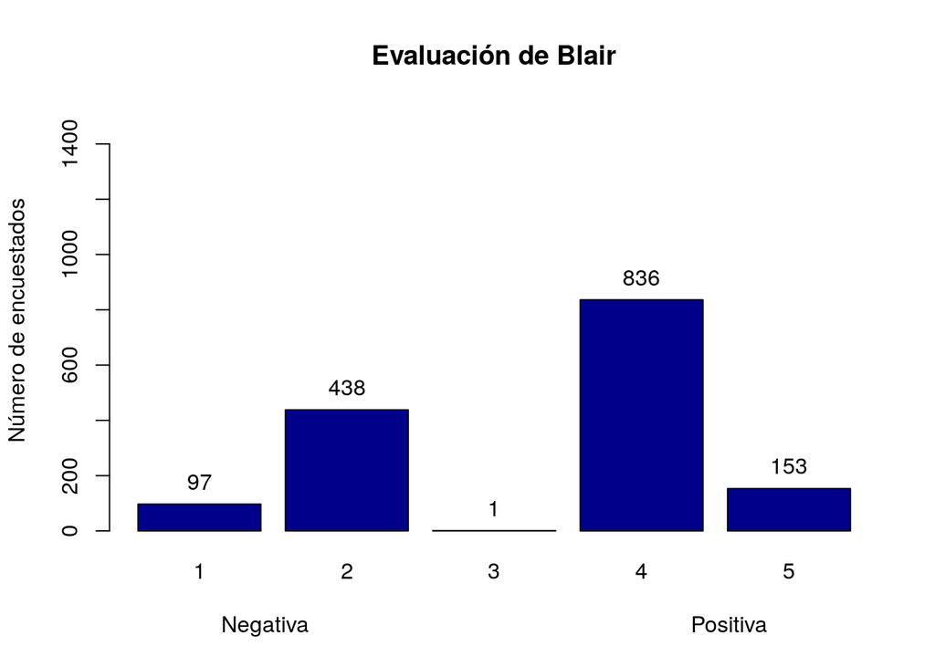

```r
# Diagrama de barras con el número de encuestados por cada valor de evaluación
tabla <- table(BEPS$Blair)
posbar <- barplot(tabla,
                  col = "darkblue",
                  ylab = "Número de encuestados",
                  xlab = "Negativa                                                             Positiva",
                  ylim=c(0, sum(tabla)),
                  main="Evaluación de Blair")
text(posbar, tabla + 80,labels=as.character(tabla))
```

> Se puede observar que 989 de 1525 encuestados realizan una evaluación más positiva del líder Laborista (evaluación superior a 3), en total el 64.85 % de los encuestados.

> **No podemos decir, por el momento, que todos los encuestados que evalúan a Blair positivamente hayan votado necesariamente al partido Laborista, pues pueden valorarlo según otros criterios y no porque pertenezca a un bando en particular. Lo mismo ocurre con el resto de líderes.**

### 2.4.2 Hague

```r
summary(BEPS$Hague)
```

```
##    Min. 1st Qu.  Median    Mean 3rd Qu.    Max.
##   1.000   2.000   2.000   2.747   4.000   5.000
```

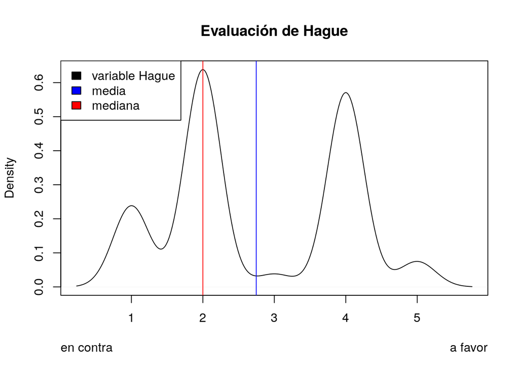

```r
plot(density(BEPS$Hague, na.rm = T), main = "Evaluación de Hague", xlab = "en contra                                                                                                 a favor")
# Marca el valor de la media con una línea azul
abline(v=mean(BEPS$Hague), col="blue")
# Marca el valor de la mediana con una línea roja
abline(v=median(BEPS$Hague), col="red")
legend("topleft", fill=c("black","blue","red"),legend = c("variable Hague","media","mediana"))
```

> La media indica que los encuestados tienden a una evaluación media baja o con tendencia más negativa que en el caso de Blair. La mediana se encuentra desplazada a la izquierda de la media debido al número encuestados que han valorado con una puntuación de 2 o inferior (por lo que se encuentra sesgada a la derecha).

En el siguiente gráfico de barras se puede observar claramente el número de encuestados por cada valor de evaluación.

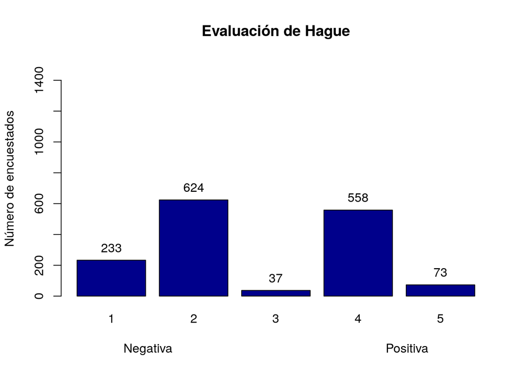

```r
# Diagrama de barras con el número de encuestados por cada valor de evaluación
tabla <- table(BEPS$Hague)
posbar <- barplot(tabla,
                  col = "darkblue",
                  ylab = "Número de encuestados",
                  xlab = "Negativa                                                             Positiva",
                  ylim=c(0, sum(tabla)),
                  main="Evaluación de Hague")
text(posbar, tabla + 80,labels=as.character(tabla))
```

> Se puede observar que 857 de 1525 encuestados realizan una evaluación más negativa del líder Conservador (evaluación inferior a 3), en total el 56.2 % de los encuestados.

### 2.4.3 Kennedy

```r
summary(BEPS$Kennedy)
```

```
##    Min. 1st Qu.  Median    Mean 3rd Qu.    Max.
##   1.000   2.000   3.000   3.135   4.000   5.000
```

[figure not shown]

```r
plot(density(BEPS$Kennedy, na.rm = T), main = "Evaluación de Hague", xlab = "en contra                                                                                                 a favor")
# Marca el valor de la media con una línea azul
abline(v=mean(BEPS$Kennedy), col="blue")
# Marca el valor de la mediana con una línea roja
abline(v=median(BEPS$Kennedy), col="red")
legend("topleft", fill=c("black","blue","red"),legend = c("variable Kennedy","media","mediana"))
```

> La media indica que los encuestados tienden a una evaluación media positiva, situándose entre Blair y Hague. La mediana se encuentra poco alejada de la media, en este caso se observa claramente en el gráfico que los valores de evaluación están bastante simétricos.

En el siguiente gráfico de barras se puede observar claramente el número de encuestados por cada valor de evaluación.

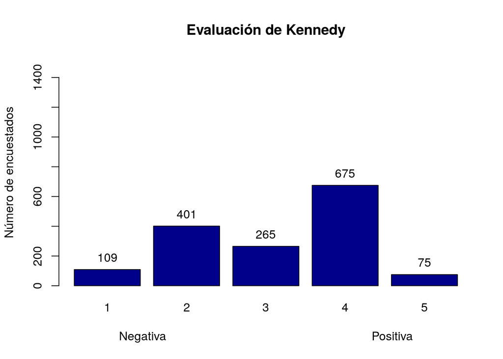

```r
# Diagrama de barras con el número de encuestados por cada valor de evaluación
tabla <- table(BEPS$Kennedy)
posbar <- barplot(tabla,
                  col = "darkblue",
                  ylab = "Número de encuestados",
                  xlab = "Negativa                                                             Positiva",
                  ylim=c(0, sum(tabla)),
                  main="Evaluación de Kennedy")
text(posbar, tabla + 80,labels=as.character(tabla))
```

> La evaluación significativa se concentra entre los valores 3 a 5, donde 1015 de 1525 encuestados realizan una evaluación media con tendencia positiva del líder Liberal Demócrata (evaluación superior a 2), en total el 66.56 % de los encuestados.

## 2.5 Variable Europe

```r
summary(BEPS$Europe)
```

```
##    Min. 1st Qu.  Median    Mean 3rd Qu.    Max.
##   1.000   4.000   6.000   6.729  10.000  11.000
```

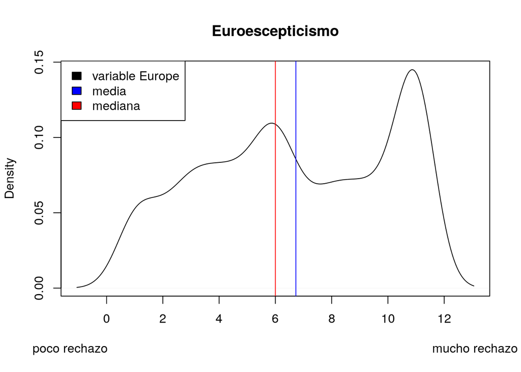

```r
plot(density(BEPS$Europe, na.rm = T), main = "Euroescepticismo", xlab = "poco rechazo                                                                                             mucho rechazo")
# Marca el valor de la media con una línea azul
abline(v=mean(BEPS$Europe), col="blue")
# Marca el valor de la mediana con una línea roja
abline(v=median(BEPS$Europe), col="red")
legend("topleft", fill=c("black","blue","red"),legend = c("variable Europe","media","mediana"))
```

> Teniendo en cuenta que 1 significa nada euroescéptico y 11 significa muy euroescéptico: el primer cuartil nos indica que por debajo de 4 puntos se encuentra el 25% de los datos y el tercer cuartil nos indica que por debajo de 10 puntos se encuentra el 75% de los datos, por lo que hay un 25% (por encima del tercer cuartil) que tienen mucho rechazo hacia Europa. La media indica que los encuestados por lo general son euroescépticos.

## 2.6 Variable Political.knowledge

> Vamos a analizar el nivel de conocimiento de los encuestados sobre la situación política de ese momento, la evaluación se hace entre 0, poco o nada de conocimiento, y 3, mucho conocimiento sobre el tema.

```r
summary(BEPS$political.knowledge)
```

```
##    Min. 1st Qu.  Median    Mean 3rd Qu.    Max.
##   0.000   0.000   2.000   1.542   2.000   3.000
```

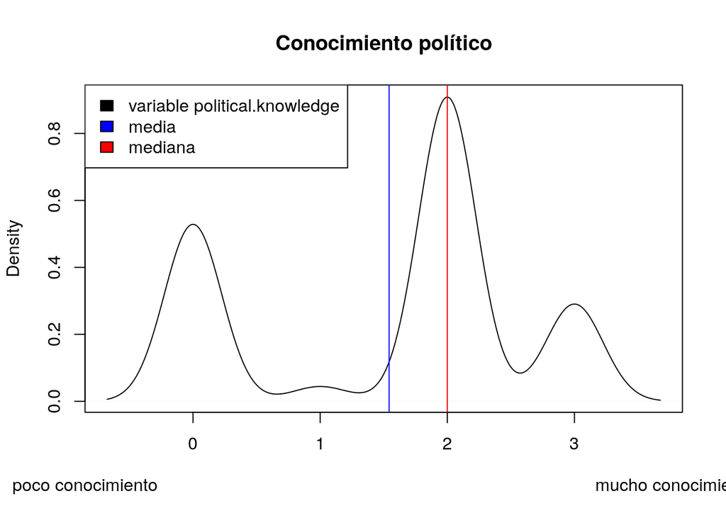

```r
plot(density(BEPS$political.knowledge, na.rm = T), main = "Conocimiento político", xlab = "poco conocimiento                                                                                          mucho conocimiento")
# Marca el valor de la media con una línea azul
abline(v=mean(BEPS$political.knowledge), col="blue")
# Marca el valor de la mediana con una línea roja
abline(v=median(BEPS$political.knowledge), col="red")
legend("topleft", fill=c("black","blue","red"),legend = c("variable political.knowledge","media","mediana"))
```

En el siguiente gráfico de barras se puede observar de manera muy simplificada la cantidad de encuestados y su nivel de conocimiento (siendo 0 nada y 3 mucho).

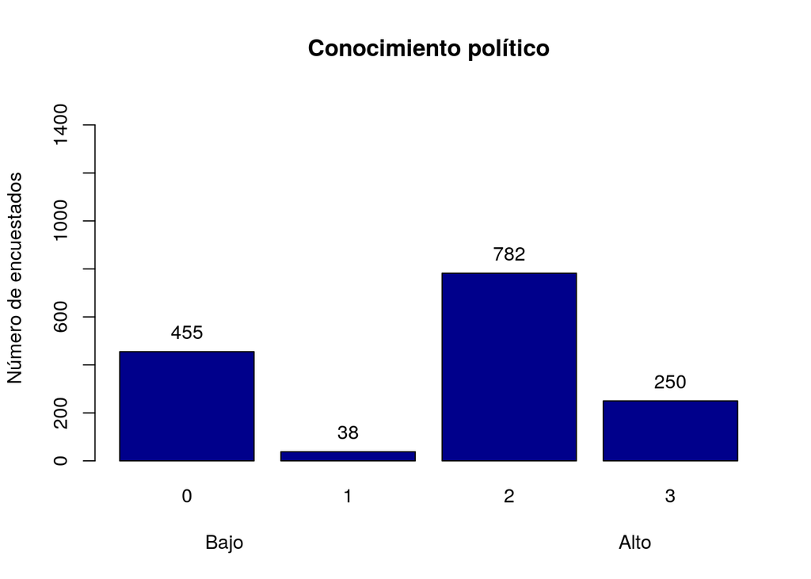

```r
tabla <- table(BEPS$political.knowledge)
# Diagrama de barras con el número de encuestados por cada nivel de conocimiento
posbar <- barplot(tabla,
                  col = "darkblue",
                  ylab = "Número de encuestados",
                  xlab = "Bajo                                                                     Alto",
                  ylim=c(0, sum(tabla)),
                  main="Conocimiento político")
text(posbar, tabla + 80,labels=as.character(tabla))
```

> Podemos ver que 1032 de 1525 encuestados tienen un nivel medio-alto de conocimiento, en total el 67.67 % de los encuestados.

## 2.7 Variable Gender

> **¿Influye el género en la intención de votar?** Emplearemos el test Chi-squared para responder a esta pregunta.

> En primera instancia podríamos pensar que el género es desechable, pues parece que no aporta un significado concluyente, ya que el género no es un atributo relevante en este análisis sobre votos en elecciones, pero de todas formas debemos realizar un pequeño estudio que nos saque de dudas.

En el siguiente diagrama de barras se puede ver visualmente la cantidad de encuestados de un género por cada bando político, donde se observa que predomina el género femenino en esta encuesta.

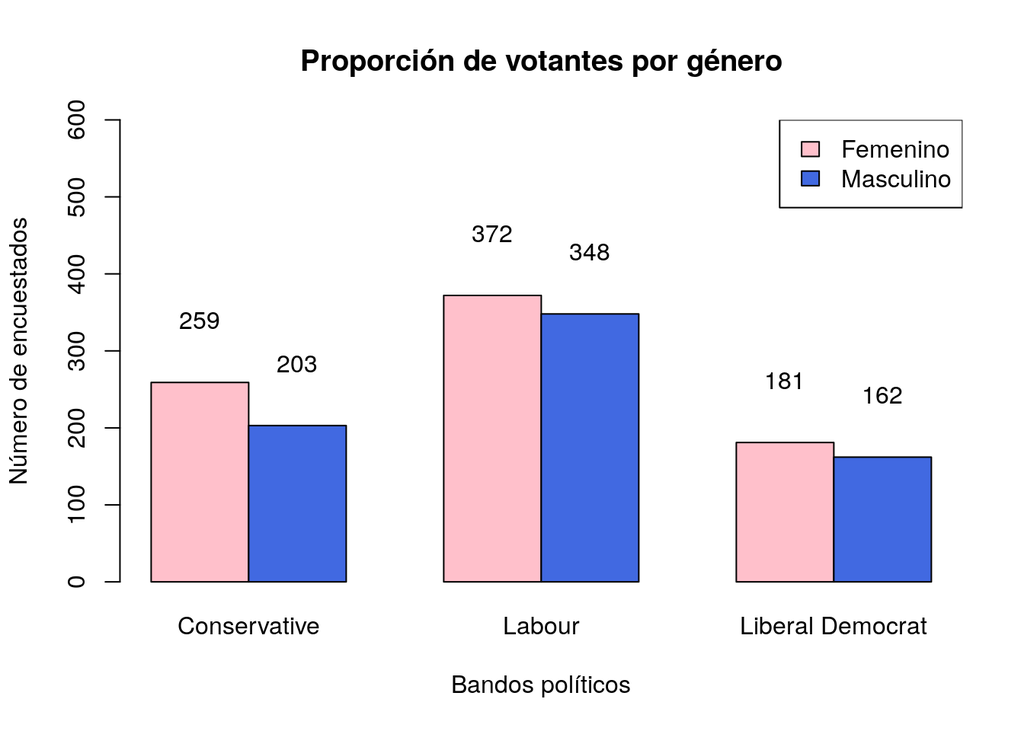

```r
# Diagrama de barras con el número de encuestados por cada valor de evaluación
tabla <- table(BEPS$gender, BEPS$vote)
posbar <- barplot(tabla,
                  col = c("pink", "royalblue"),
                  ylab = "Número de encuestados",
                  xlab = "Bandos políticos",
                  ylim=c(0, 600),
                  main="Proporción de votantes por género",
                  beside = TRUE)
legend("topright", c("Femenino","Masculino"), fill = c("pink","royalblue"))
text(posbar, tabla + 80,labels=as.character(tabla))
```

Vamos a probar la hipótesis de si el género es independiente del voto en las elecciones, por lo que aplicamos el test ChiSquared a la tabla de contingencia.

```r
# Aplicamos el test ChiSquared a la tabla
chisq.test(table(BEPS$gender, BEPS$vote))
```

```
##
##  Pearson's Chi-squared test
##
## data:  table(BEPS$gender, BEPS$vote)
## X-squared = 2.2228, df = 2, p-value = 0.3291
```

> Asumiendo un nivel de significancia del p-valor del 5%, podemos ver que el p-valor es de 0.3291 por lo que no es significativo, ya que cuanto más próximo a 0 mayor es la relación entre las variables.

> **Según este análisis de Chi-Square, el género no se encuentra tan correlacionada con la variable de respuesta *voto*. Por otra parte, no sabemos de que forma está correlacionada con el resto de variables. Por lo que, no podemos descartarla del estudio porque no hemos aplicado un método específico para concluir que podemos eliminarla (como por ejemplo, métodos específicos que podemos encontrar en caret). Esto es simplemente un estudio superficial de la variable**.

# 3 Tratamiento de valores nulos, extremos, atípicos o desconocidos

Primero analizamos si entre nuestros datos hay valores nulos que puedan ser descartados:

```r
mytable = table(BEPS)
cat("El número de nulos iniciales es",sum(is.na(mytable)),"\n")
```

```
## El número de nulos iniciales es 0
```

> Con respecto a valores extremos y atípicos, como hemos podido observar en el análisis individual de las variables, no había mínimos y máximos muy disparatados, y a parte, la media no estaba muy alejada de la mediana, tenían valores próximos. Por lo que podemos afirmar que no hay valores extremos y atípicos.

> En cuanto a valores desconocidos, no hay constancia de que los haya.

# 4 Análisis de componentes principales

## 4.1 Estudio de la varianza y escalado de los datos

Vamos a estudiar la varianza de nuestras variables, para saber su valor y ver si nos conviene escalar los datos de cara a que no tengamos ningún problema a la hora de aplicar los diferentes modelos posteriormente.

Media:

```r
apply(BEPS[2:9], 2, mean)
```

```
##                     age  economic.cond.national economic.cond.household
##               54.182295                3.245902                3.140328
##                   Blair                   Hague                 Kennedy
##                3.334426                2.746885                3.135082
##                  Europe     political.knowledge
##                6.728525                1.542295
```

Varianza:

```r
apply(BEPS[2:9], 2, var)
```

```
##                     age  economic.cond.national economic.cond.household
##             246.8420748               0.7761069               0.8648096
##                   Blair                   Hague                 Kennedy
##               1.3802117               1.5146310               1.1707173
##                  Europe     political.knowledge
##              10.8737593               1.1735708
```

> Como podemos ver, la variable edad, tiene una varianza bastante elevada con respecto a las demás variables, de hecho, si nos fijamos en nuestros datos, podemos ver que mientras que la mayoría se mueven en rangos numéricos del 1 al 5, o como mucho del 1 al 11, la variable edad se mueve en un rango de entre 24 y 93 años. Esto puede ser un problema de cara a aplicar diferentes modelos, ya que el algoritmo puede interpretar que le debe dar más prioridad a esa variable, sobre todo en algoritmos no lineales, por lo que conviene escalar los datos para que tengan varianzas y medias aproximadas.

Antes de escalarlos pasaremos la variable gender a numérico y la escalaremos con el resto de datos para, como ya hemos dicho, que todos los datos numéricos tengan una varianza y media aproximadas.

```r
gender <- as.numeric(BEPS$gender)
gender <- data.frame(gender)
BEPS <- data.frame(BEPS[1:9], gender)

scaled_data = apply(BEPS[2:10], 2, scale)
apply(scaled_data, 2, var)
```

```
##                     age  economic.cond.national economic.cond.household
##                       1                       1                       1
##                   Blair                   Hague                 Kennedy
##                       1                       1                       1
##                  Europe     political.knowledge                  gender
##                       1                       1                       1
```

```r
apply(scaled_data, 2, mean)
```

```
##                     age  economic.cond.national economic.cond.household
##            9.928804e-17           -5.889244e-17            6.420292e-17
##                   Blair                   Hague                 Kennedy
##            1.241937e-16            6.980584e-17           -1.701468e-16
##                  Europe     political.knowledge                  gender
##           -1.023255e-16           -8.534427e-17            5.282859e-17
```

```r
BEPS <- data.frame(BEPS[1], scaled_data)
str(BEPS)
```

```
## 'data.frame':    1525 obs. of  10 variables:
##  $ vote                   : Factor w/ 3 levels "Conservative",..: 3 2 2 2 2 2 3 2 2 2 ...
##  $ age                    : num  -0.712 -1.157 -1.221 -1.921 -0.839 ...
##  $ economic.cond.national : num  -0.279 0.856 0.856 0.856 -1.414 ...
##  $ economic.cond.household: num  -0.151 0.924 0.924 -1.226 -1.226 ...
##  $ Blair                  : num  0.567 0.567 1.418 -1.136 -1.987 ...
##  $ Hague                  : num  -1.419 1.018 -0.607 -1.419 -1.419 ...
##  $ Kennedy                : num  0.799 0.799 -0.125 -0.125 0.799 ...
##  $ Europe                 : num  -1.434 -0.524 -1.131 -0.827 -0.221 ...
##  $ political.knowledge    : num  0.423 0.423 0.423 -1.424 0.423 ...
##  $ gender                 : num  -0.937 1.067 1.067 -0.937 1.067 ...
```

> Una vez escalados los datos, es decir, que tengan una varianza y media aproximadas, modificamos BEPS para que contenga los datos escalados y elimine los no escalados. De esta manera, ya podemos utilizar la técnica de PCA para poder representar todas las variables en un mismo espacio.

## 4.2 Relaciones de correlación entre variables

### 4.2.1 Relación de los predictores con la variable de respuesta

Vamos a ver cómo se relacionan los predictores con la variable *vote* a predecir.

```r
library(caret)
```

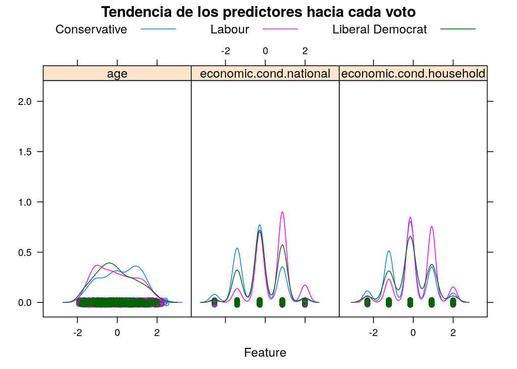

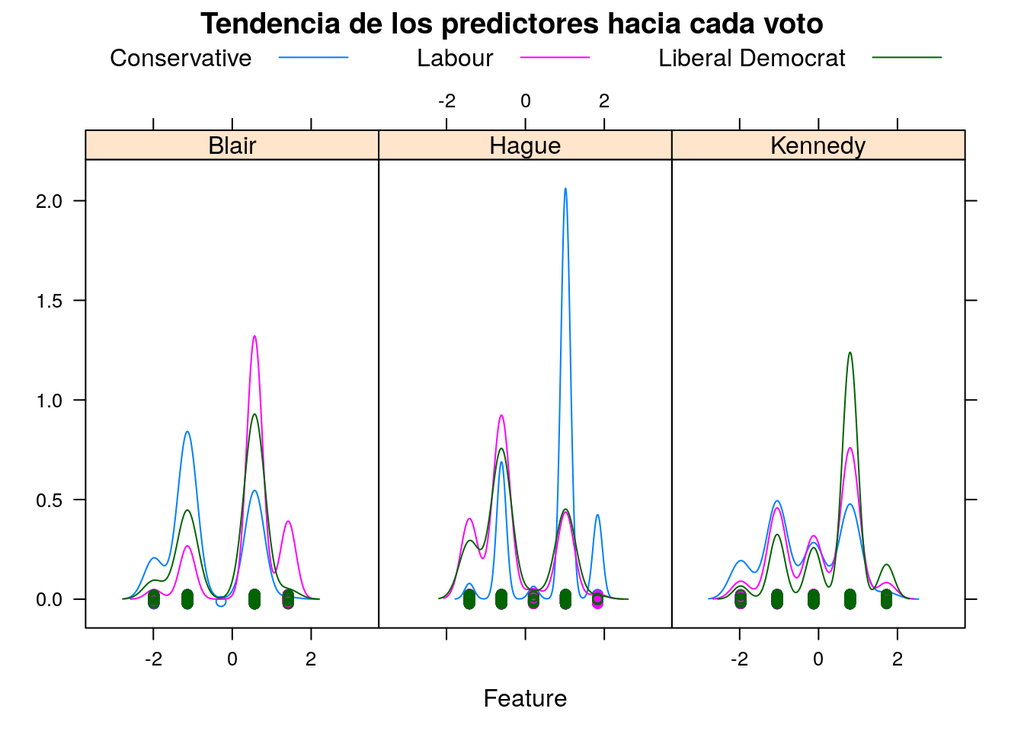

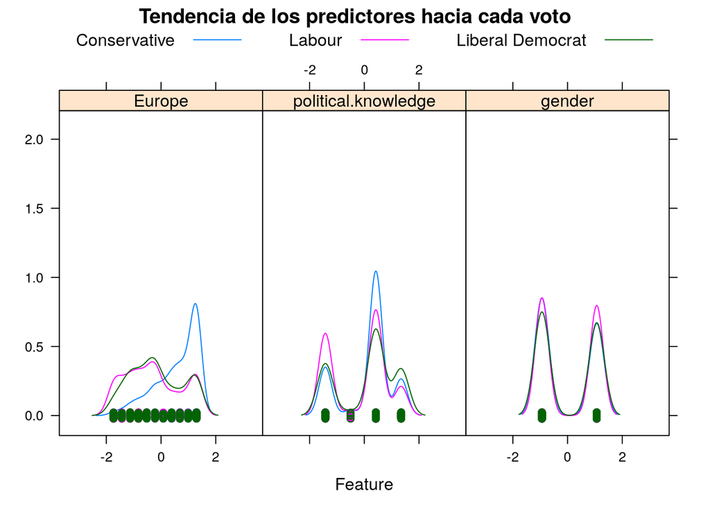

```r
library(ggplot2)
featurePlot( x=BEPS[2:10], y=BEPS$vote, plot="density", layout = c(3, 1), auto.key = list(columns = 3), main="Tendencia de los predictores hacia cada voto")
```

Mediante estas gráficas se puede clasificar mejor hacia qué partido tienden más los valores de cada predictor.

En el caso de los líderes políticos, su evaluación positiva hace que el voto vaya más dirigido al partido que representan: para Hague el partido Conservador, para Blair el partido Laborista y para Kennedy el partido Liberal Demócrata.

En cuanto a la edad se puede ver que cuanto más avanzada sea, más tiende al voto conservador, y cuanto más joven tiende al partido Laborista. Para la mediana edad se mantiene en el voto Liberal Demócrata.

Según la percepción de la economía nacional y doméstica (ambos recogen unos resultados muy parecidos), cuanto más positiva los votos tienden al partido Laborista, y cuanto más negativa los votos tienden al partido Conservador.

Con respecto al conocimiento político: tiende al partido Conservador cuanto más creen los encuestados que entienden sobre el tema y al Laborista cuanto menos.

En la actitud del encuestado hacia Europa, tienden al partido Conservador aquellos que son más euroescépticos, por el contrario los otros dos partidos son más pro-europeos.

Para el caso del número de votantes repartidos por género, vemos que en ambos géneros el partido Laborista ha resultado el más votado.

> Como deducción a la información que nos ofrece el gráfico anterior, se podría decir que los encuestados con una edad más avanzada de la media, con una percepción de la economía nacional y doméstica con tendencia más negativa, con un nivel medio alto de conocimiento sobre el tema, que hayan evaluado positivamente a Hague y tengan una actitud euroescéptica es más probable que voten al partido Conservador.

> Por otro lado, se podría decir que los encuestados más jóvenes, con una percepción de la economía nacional y doméstica con tendencia más positiva, con un nivel medio bajo de conocimiento sobre el tema, que hayan evaluado positivamente a Blair y sean pro-europeos es más probable que voten al partido Laborista.

> Sin embargo, es más difícil según la distribución de estos datos predecir el voto Liberal Demócrata.

> **Pero como hemos mencionado, estos estudios no son determinantes pues las variables están siendo estudiadas de forma independiente.**

### 4.2.2 Correlación entre variables

Vamos a comprobar si existe alguna relación entre los predictores, aplicaremos el test de correlación de Pearson para analizarlo. En la siguiente gráfica se observa que, cuanto más grande el círculo, más correlación entre las variables, y el color indica el signo (correlación positiva o negativa). Además se incluye en la parte inferior el valor de la correlación para poder indentificarlo más fácilmente.

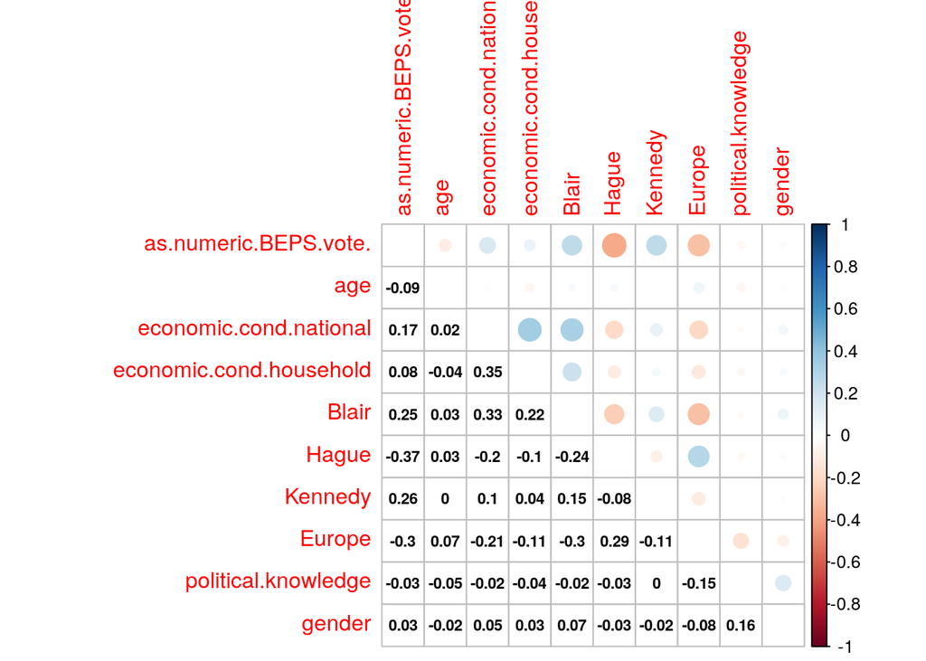

```r
#install.packages("corrplot")
library(corrplot)
aux <- data.frame(as.numeric(BEPS$vote), BEPS[2:10])
corrplot.mixed(cor(aux, method = "pearson"), lower.col = "black", number.cex = 0.7, tl.pos = "lt")
```

Pero en general, **se puede ver como no existen correlaciones muy extremas**, aún así podemos analizar las correlaciones más destacadas. Aunque también debemos distinguir la casualidad de una correlación real, por lo que aplicamos algunas pruebas entre predictores para comprobarlo.

#### 4.2.2.1 Correlación entre predictores

Comparamos la correlación entre *economic.cond.national* con *economic.cond.household*:

```r
summary(lm(BEPS$economic.cond.national ~ BEPS$economic.cond.household, data=BEPS[2:10]))
```

```
##
## Call:
## lm(formula = BEPS$economic.cond.national ~ BEPS$economic.cond.household,
##     data = BEPS[2:10])
##
## Residuals:
##     Min      1Q  Median      3Q     Max
## -3.2419 -0.5993 -0.2269  0.5359  2.7881
##
## Coefficients:
##                               Estimate Std. Error t value Pr(>|t|)
## (Intercept)                  4.255e-16  2.403e-02    0.00        1
## BEPS$economic.cond.household 3.463e-01  2.404e-02   14.41   <2e-16 ***
## ---
## Signif. codes:  0 '***' 0.001 '**' 0.01 '*' 0.05 '.' 0.1 ' ' 1
##
## Residual standard error: 0.9384 on 1523 degrees of freedom
## Multiple R-squared:  0.1199, Adjusted R-squared:  0.1193
## F-statistic: 207.5 on 1 and 1523 DF,  p-value: < 2.2e-16
```

> Se puede ver que el modelo presenta un valor alto de F-statistic y un valor muy pequeño de p-value por lo que se puede afirmar que no es por azar, el error estándar residual es alto según el valor máximo residual de 2.7881 y el R-squared no es un valor pequeño. Además nos indica con tres asteriscos que están relacionados, por lo que **todo apunta a una alta relación entre las variables.**

Comparamos la correlación entre *economic.cond.national* con la variable *Blair*:

```r
summary(lm(BEPS$economic.cond.national ~ BEPS$Blair, data=BEPS[2:10]))
```

```
##
## Call:
## lm(formula = BEPS$economic.cond.national ~ BEPS$Blair, data = BEPS[2:10])
##
## Residuals:
##      Min       1Q   Median       3Q      Max
## -3.01278 -0.46431  0.09216  0.67080  2.36239
##
## Coefficients:
##              Estimate Std. Error t value Pr(>|t|)
## (Intercept) 3.081e-16  2.421e-02     0.0        1
## BEPS$Blair  3.269e-01  2.422e-02    13.5   <2e-16 ***
## ---
## Signif. codes:  0 '***' 0.001 '**' 0.01 '*' 0.05 '.' 0.1 ' ' 1
##
## Residual standard error: 0.9454 on 1523 degrees of freedom
## Multiple R-squared:  0.1068, Adjusted R-squared:  0.1063
## F-statistic: 182.2 on 1 and 1523 DF,  p-value: < 2.2e-16
```

> El modelo presenta un valor alto de F-statistic y un valor muy pequeño de p-value por lo que se puede afirmar que no es por azar, el error estándar residual es alto según el valor máximo residual de 2.36239 y el R-squared no es un valor pequeño. Vemos los tres asteriscos, por lo que **todo apunta a una alta relación entre las variables.**

Comparamos la correlación entre *Europe* con la variable *Blair*:

```r
summary(lm(BEPS$Europe ~ BEPS$Blair, data=BEPS[2:10]))
```

```
##
## Call:
## lm(formula = BEPS$Europe ~ BEPS$Blair, data = BEPS[2:10])
##
## Residuals:
##      Min       1Q   Median       3Q      Max
## -2.32570 -0.71082 -0.05314  0.85662  1.71523
##
## Coefficients:
##               Estimate Std. Error t value Pr(>|t|)
## (Intercept) -2.298e-16  2.447e-02     0.0        1
## BEPS$Blair  -2.962e-01  2.447e-02   -12.1   <2e-16 ***
## ---
## Signif. codes:  0 '***' 0.001 '**' 0.01 '*' 0.05 '.' 0.1 ' ' 1
##
## Residual standard error: 0.9555 on 1523 degrees of freedom
## Multiple R-squared:  0.08771,    Adjusted R-squared:  0.08711
## F-statistic: 146.4 on 1 and 1523 DF,  p-value: < 2.2e-16
```

> El modelo presenta un valor alto de F-statistic y un valor muy pequeño de p-value por lo que se puede afirmar que no es por azar, el error estándar residual es alto según el valor máximo residual de 1.71523 y el R-squared no es un valor pequeño. Vemos los tres asteriscos, por lo que **todo apunta a una alta relación entre las variables.**

Comparamos la correlación entre *Europe* con la variable *Hague*:

```r
summary(lm(BEPS$Europe ~ BEPS$Hague, data=BEPS[2:10]))
```

```
##
## Call:
## lm(formula = BEPS$Europe ~ BEPS$Hague, data = BEPS[2:10])
##
## Residuals:
##      Min       1Q   Median       3Q      Max
## -2.26328 -0.72283 -0.04654  0.86323  1.70322
##
## Coefficients:
##               Estimate Std. Error t value Pr(>|t|)
## (Intercept) -6.088e-16  2.454e-02    0.00        1
## BEPS$Hague   2.873e-01  2.454e-02   11.71   <2e-16 ***
## ---
## Signif. codes:  0 '***' 0.001 '**' 0.01 '*' 0.05 '.' 0.1 ' ' 1
##
## Residual standard error: 0.9581 on 1523 degrees of freedom
## Multiple R-squared:  0.08257,    Adjusted R-squared:  0.08197
## F-statistic: 137.1 on 1 and 1523 DF,  p-value: < 2.2e-16
```

> El modelo presenta un valor alto de F-statistic y un valor muy pequeño de p-value por lo que se puede afirmar que no es por azar, el error estándar residual es alto según el valor máximo residual de 1.70322 y el R-squared no es un valor pequeño. Vemos los tres asteriscos, por lo que **todo apunta a una alta relación entre las variables.**

Comparamos la correlación entre *Europe* con la variable *Kennedy*:

```r
summary(lm(BEPS$Europe ~ BEPS$Kennedy, data=BEPS[2:10]))
```

```
##
## Call:
## lm(formula = BEPS$Europe ~ BEPS$Kennedy, data = BEPS[2:10])
##
## Residuals:
##     Min      1Q  Median      3Q     Max
## -1.9535 -0.7405 -0.1333  1.0790  1.4843
##
## Coefficients:
##                Estimate Std. Error t value Pr(>|t|)
## (Intercept)  -2.961e-16  2.546e-02   0.000        1
## BEPS$Kennedy -1.096e-01  2.547e-02  -4.304 1.78e-05 ***
## ---
## Signif. codes:  0 '***' 0.001 '**' 0.01 '*' 0.05 '.' 0.1 ' ' 1
##
## Residual standard error: 0.9943 on 1523 degrees of freedom
## Multiple R-squared:  0.01202,    Adjusted R-squared:  0.01137
## F-statistic: 18.52 on 1 and 1523 DF,  p-value: 1.784e-05
```

Comparamos la correlación entre *Age* con la variable *Political.knowledge*:

```r
summary(lm(BEPS$age ~ BEPS$political.knowledge, data=BEPS[2:10]))
```

```
##
## Call:
## lm(formula = BEPS$age ~ BEPS$political.knowledge, data = BEPS[2:10])
##
## Residuals:
##      Min       1Q   Median       3Q      Max
## -1.99010 -0.83744 -0.05476  0.81045  2.49119
##
## Coefficients:
##                            Estimate Std. Error t value Pr(>|t|)
## (Intercept)               1.759e-16  2.559e-02   0.000   1.0000
## BEPS$political.knowledge -4.849e-02  2.559e-02  -1.895   0.0583 .
## ---
## Signif. codes:  0 '***' 0.001 '**' 0.01 '*' 0.05 '.' 0.1 ' ' 1
##
## Residual standard error: 0.9992 on 1523 degrees of freedom
## Multiple R-squared:  0.002351,   Adjusted R-squared:  0.001696
## F-statistic: 3.589 on 1 and 1523 DF,  p-value: 0.05834
```

#### 4.2.2.2 Correlación con la variable de respuesta

```r
cons <- BEPS$vote
levels(cons) <- c("Conservative", "Labour/Lib.Demo.", "Labour/Lib.Demo.")

lab <- BEPS$vote
levels(lab) <- c("Conser/Lib.Demo.", "Labour", "Conser/Lib.Demo.")

lib.demo <- BEPS$vote
levels(lib.demo) <- c("Conser/Labour", "Conser/Labour", "Liberal Democrat")


head(cons)
```

```
## [1] Labour/Lib.Demo. Labour/Lib.Demo. Labour/Lib.Demo. Labour/Lib.Demo.
## [5] Labour/Lib.Demo. Labour/Lib.Demo.
## Levels: Conservative Labour/Lib.Demo.
```

```r
head(lab)
```

```
## [1] Conser/Lib.Demo. Labour           Labour           Labour
## [5] Labour           Labour
## Levels: Conser/Lib.Demo. Labour
```

```r
head(lib.demo)
```

```
## [1] Liberal Democrat Conser/Labour    Conser/Labour    Conser/Labour
## [5] Conser/Labour    Conser/Labour
## Levels: Conser/Labour Liberal Democrat
```

Se puede observar que ahora son factores de dos niveles.

Comparamos la correlación entre los votos con cada uno de los predictores:

```r
summary(glm(as.numeric(cons) ~ ., data=BEPS[2:10]), family=binomial)
```

```
##
## Call:
## glm(formula = as.numeric(cons) ~ ., data = BEPS[2:10])
##
## Deviance Residuals:
##     Min       1Q   Median       3Q      Max
## -1.2090  -0.2281   0.0459   0.2435   0.9584
##
## Coefficients:
##                          Estimate Std. Error t value Pr(>|t|)
## (Intercept)              1.697049   0.009015 188.251  < 2e-16 ***
## age                     -0.047423   0.009076  -5.225 1.99e-07 ***
## economic.cond.national   0.044259   0.010137   4.366 1.35e-05 ***
## economic.cond.household  0.008986   0.009700   0.926    0.354
## Blair                    0.107331   0.010086  10.642  < 2e-16 ***
## Hague                   -0.148451   0.009620 -15.431  < 2e-16 ***
## Kennedy                  0.058009   0.009158   6.334 3.14e-10 ***
## Europe                  -0.092743   0.009935  -9.335  < 2e-16 ***
## political.knowledge     -0.068292   0.009275  -7.363 2.94e-13 ***
## gender                   0.006106   0.009175   0.666    0.506
## ---
## Signif. codes:  0 '***' 0.001 '**' 0.01 '*' 0.05 '.' 0.1 ' ' 1
##
## (Dispersion parameter for gaussian family taken to be 0.1239328)
##
##     Null deviance: 322.04  on 1524  degrees of freedom
## Residual deviance: 187.76  on 1515  degrees of freedom
## AIC: 1155.5
##
## Number of Fisher Scoring iterations: 2
```

Para el bando Conservador, los resultados indican que las variables *economic.cond.household* y *gender* son las que menos correlación tienen con la variable de respuesta.

```r
summary(glm(as.numeric(lab) ~ ., data=BEPS[2:10]), family=binomial)
```

```
##
## Call:
## glm(formula = as.numeric(lab) ~ ., data = BEPS[2:10])
##
## Deviance Residuals:
##      Min        1Q    Median        3Q       Max
## -0.92705  -0.33704   0.03218   0.33248   1.18630
##
## Coefficients:
##                          Estimate Std. Error t value Pr(>|t|)
## (Intercept)              1.472131   0.010711 137.440  < 2e-16 ***
## age                     -0.036171   0.010784  -3.354 0.000816 ***
## economic.cond.national   0.068008   0.012045   5.646 1.95e-08 ***
## economic.cond.household  0.026947   0.011525   2.338 0.019513 *
## Blair                    0.143683   0.011984  11.990  < 2e-16 ***
## Hague                   -0.095888   0.011430  -8.389  < 2e-16 ***
## Kennedy                 -0.028973   0.010881  -2.663 0.007833 **
## Europe                  -0.063780   0.011805  -5.403 7.60e-08 ***
## political.knowledge     -0.086086   0.011020  -7.812 1.05e-14 ***
## gender                   0.004927   0.010901   0.452 0.651352
## ---
## Signif. codes:  0 '***' 0.001 '**' 0.01 '*' 0.05 '.' 0.1 ' ' 1
##
## (Dispersion parameter for gaussian family taken to be 0.174958)
##
##     Null deviance: 380.07  on 1524  degrees of freedom
## Residual deviance: 265.06  on 1515  degrees of freedom
## AIC: 1681.3
##
## Number of Fisher Scoring iterations: 2
```

Para el bando Laborista, los resultados indican que las variables *economic.cond.household* y *gender*, al igual que con el bando Conservador, son las que menos correlación tienen con la variable de respuesta.

```r
summary(glm(as.numeric(lib.demo) ~ ., data=BEPS[2:10]), family=binomial)
```

```
##
## Call:
## glm(formula = as.numeric(lib.demo) ~ ., data = BEPS[2:10])
##
## Deviance Residuals:
##      Min        1Q    Median        3Q       Max
## -0.52497  -0.26350  -0.15939  -0.00786   1.04225
##
## Coefficients:
##                          Estimate Std. Error t value Pr(>|t|)
## (Intercept)              1.224918   0.010306 118.850  < 2e-16 ***
## age                     -0.011252   0.010377  -1.084  0.27838
## economic.cond.national  -0.023749   0.011590  -2.049  0.04061 *
## economic.cond.household -0.017960   0.011090  -1.620  0.10554
## Blair                   -0.036352   0.011531  -3.153  0.00165 **
## Hague                   -0.052563   0.010998  -4.779 1.93e-06 ***
## Kennedy                  0.086982   0.010470   8.308  < 2e-16 ***
## Europe                  -0.028963   0.011359  -2.550  0.01088 *
## political.knowledge      0.017794   0.010604   1.678  0.09354 .
## gender                   0.001179   0.010489   0.112  0.91051
## ---
## Signif. codes:  0 '***' 0.001 '**' 0.01 '*' 0.05 '.' 0.1 ' ' 1
##
## (Dispersion parameter for gaussian family taken to be 0.161989)
##
##     Null deviance: 265.85  on 1524  degrees of freedom
## Residual deviance: 245.41  on 1515  degrees of freedom
## AIC: 1563.9
##
## Number of Fisher Scoring iterations: 2
```

En este caso, las variables están menos correlacionadas. Destacamos: *age*, *economic.cond.household*, *political.knowledge* y *gender* como las menos correlacionadas con el voto. Y con poca correlación tenemos *economic.cond.national* y *Europe*.

## 4.3 Técnica PCA

> Para poder representar nuestras variables, tenemos un problema, y es que necesitaríamos muchas dimensiones, una por cada variable a representar. Por lo que necesitamos emplear PCA para **proyectar todas esas dimensiones en un solo plano** y poder representar todas nuestras variables en tan solo dos o tres dimensiones como mucho, reduciendo el número de variables.

```r
pca_result = prcomp(BEPS[2:10], scale = TRUE)
names(pca_result)
```

```
## [1] "sdev"     "rotation" "center"   "scale"    "x"
```

El “center” y “scale” se refieren respectivamente a las medias y desviaciones estándar de los predictores que se han usado para escalar antes de usar PCA. Por otra parte, “rotation” se refiere a las cargas empleadas para calcular los componentes principales.

```r
pca_result$center
```

```
##                     age  economic.cond.national economic.cond.household
##            9.917044e-17           -5.893282e-17            6.421093e-17
##                   Blair                   Hague                 Kennedy
##            1.244906e-16            6.961644e-17           -1.700825e-16
##                  Europe     political.knowledge                  gender
##           -1.026865e-16           -8.561458e-17            5.299950e-17
```

```r
pca_result$scale
```

```
##                     age  economic.cond.national economic.cond.household
##                       1                       1                       1
##                   Blair                   Hague                 Kennedy
##                       1                       1                       1
##                  Europe     political.knowledge                  gender
##                       1                       1                       1
```

```r
pca_result$rotation
```

```
##                                 PC1         PC2         PC3         PC4
## age                      0.03946517  0.27290838 -0.07873937  0.89101244
## economic.cond.national  -0.47225010  0.22911673  0.27548188  0.04275095
## economic.cond.household -0.36449835  0.26917778  0.50401376 -0.14790712
## Blair                   -0.48655120  0.10939351 -0.06628828  0.13398829
## Hague                    0.39248507  0.09303247  0.28946994  0.10343807
## Kennedy                 -0.20682764  0.07940970 -0.57665151  0.09586463
## Europe                   0.43561118  0.28963992  0.24334820  0.06279823
## political.knowledge     -0.06384932 -0.67678706  0.02291885  0.14214265
## gender                  -0.12318761 -0.48136262  0.42827843  0.34699019
##                                 PC5         PC6         PC7         PC8
## age                     -0.22268394  0.18446495 -0.09337572  0.17627528
## economic.cond.national   0.06383439  0.14490572 -0.05762160 -0.35907602
## economic.cond.household  0.19867491  0.29281976 -0.24085121  0.40453431
## Blair                   -0.04121296 -0.15950249  0.52227552 -0.43493607
## Hague                    0.47186334  0.23052931  0.66433191  0.09673558
## Kennedy                  0.75345818 -0.03188068 -0.18900775  0.06781605
## Europe                   0.22253725 -0.09451645 -0.40084663 -0.61728144
## political.knowledge      0.08010348  0.63372321 -0.10999905 -0.28229454
## gender                   0.24263793 -0.60752938 -0.08568009  0.11176164
##                                 PC9
## age                     -0.02128386
## economic.cond.national   0.69959926
## economic.cond.household -0.41461481
## Blair                   -0.48976865
## Hague                    0.12772910
## Kennedy                  0.01268385
## Europe                  -0.25103597
## political.knowledge     -0.13168548
## gender                   0.03864427
```

Por otro lado, para que nuestros resultados vayan en dirección positiva a la hora de representarlos, podemos cambiar su signo.

```r
pca_result$x = - pca_result$x
pca_result$rotation = - pca_result$rotation
head(pca_result$x)
```

```
##          PC1        PC2        PC3        PC4         PC5        PC6
## 1  1.3755767  0.5557693  1.7467575 0.97310285  0.49268773 -0.3133975
## 2  1.2149474  0.6019939 -0.9281034 0.47611218 -1.73145478  0.0306994
## 3  2.3424800  0.9264975 -0.7916346 0.71355793 -0.11239868  0.4660475
## 4  0.1658748 -0.2503384  1.1297306 2.38408629  1.00368352  0.9863702
## 5 -1.0714481  2.0324845  1.2688702 0.54675939 -0.11088607  1.1140228
## 6  0.4010537  0.9056129 -1.5523773 0.09705192 -0.04288251 -0.0215590
##           PC7         PC8        PC9
## 1  0.07069934 -0.24541009  0.2980576
## 2 -0.72955446 -0.09242999 -0.2201020
## 3 -0.51825993  0.13449473  0.2624670
## 4  0.51865977 -0.01416731 -1.8805619
## 5  1.72598500 -0.78134197 -0.3799467
## 6 -1.20051344 -0.68527996  0.5362411
```

> En la siguiente gráfica podemos ver todas nuestras variables representadas en un mismo plano.

Para un análisis más legible, se han agrupado los puntos por cada bando político en colores y para observar los límites entre clusters se han unido sus puntos más externos. También se puede observar la influencia direccional que cada variable tiene en los componentes principales.

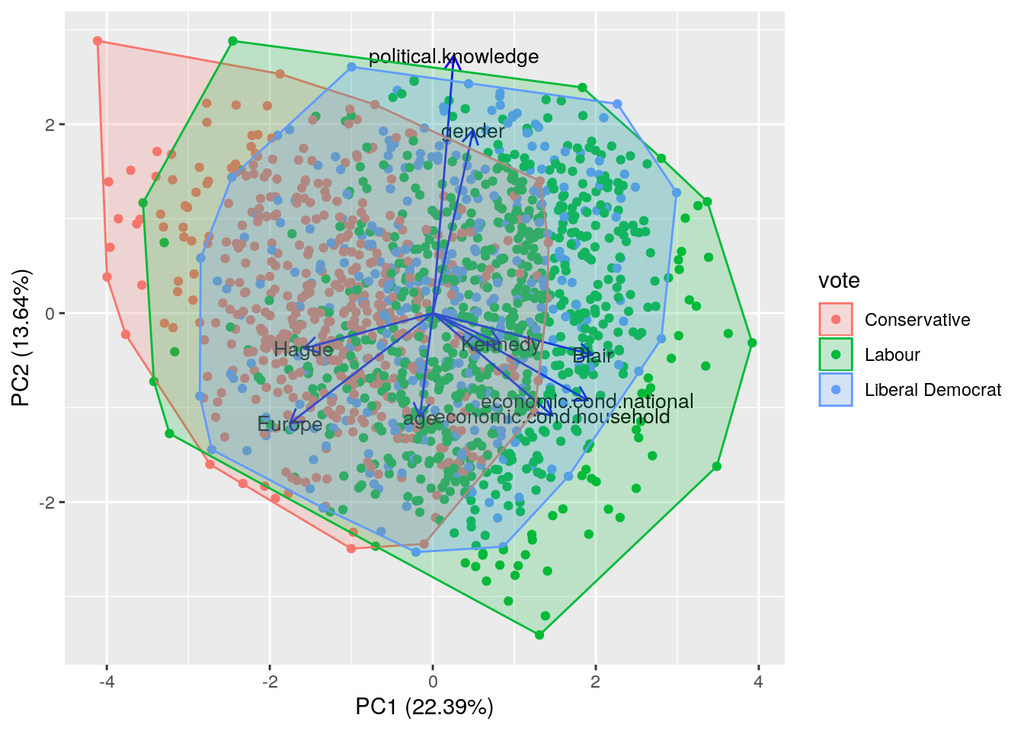

```r
# install.packages("ggfortify")
library(ggfortify)
library(ggplot2)

autoplot(pca_result, data=BEPS, scale = 0, cex=0.7, colour='vote',
         frame = TRUE,
         loadings = TRUE,
         loadings.colour = 'blue',
         loadings.label = TRUE,
         loadings.label.size = 3.5,
         loadings.label.colour= 'black')
```

Es importante destacar que un vector que apunta a algún sentido horizontal (izquierda o derecha) refleja una fuerte influencia en el primer PCA, y si apunta en sentido vertical (arriba o abajo) está reflejando una fuerte influencia en el segundo PCA.

Los vectores que apuntan a la misma dirección significa que están correlacionados positivamente y los que forman un ángulo de 180º están correlacionados negativamente. Aquellos que forman un ángulo de 90º (ortogonales) probablemente no lo estén.

Vamos a analizar la proporción de varianza explicada por cada componente principal.

```r
# Obtenemos la varianza de la desviación estándar y los ajustamos al cuadrado
VE <- pca_result$sdev^2
PVE <- VE / sum(VE)
PVE <- round(PVE, 2)

tabla <- data.frame(cbind(c("PC1", "PC2","PC3","PC4","PC5","PC6","PC7", "PC8"), PVE))
colnames(tabla) <- c("Componente", "% Varianza")
tabla
```

| Componente | % Varianza |
| --- | --- |
| PC1 | 0.22 |
| PC2 | 0.14 |
| PC3 | 0.11 |
| PC4 | 0.11 |
| PC5 | 0.1 |
| PC6 | 0.09 |
| PC7 | 0.08 |
| PC8 | 0.07 |
| PC1 | 0.07 |

Como podemos ver en la tabla, el primer componente explica el 22% de la varianza en los datos, el segundo componente explica el 14% de la varianza, y el siguiente un 11%, así sucesivamente.

Al tomar los dos primeros componentes principales solo se puede explicar el 36% de la varianza lo que no es suficiente, por lo que una sola gráfica no proporciona la información que necesitamos.

> **El estudio PCA realizado no es determinante**, ya que este análisis pretende reducir al menor número posible de componentes principales para explicar la mayor parte de la variabilidad y, en este caso, no es posible hacerlo porque solo un 36% de la varianza es explicada por los 2 primeros componentes principales.

## 4.4 Conclusiones finales sobre el estudio de la variables

> **¿Es correcto este espacio de predicciones?**, es decir, ¿el número de predictores que disponemos es suficiente para encontrar una buena solución o tenemos más de los necesarios?

# 5 Aplicando los algoritmos de Machine Learning

## 5.1 Algoritmos de Machine Learning empleados

> Se van a emplear los algoritmos *lda* (Análisis Discriminante Lineal), como ejemplo de modelo lineal y tipo sencillo; *rpart* (El algoritmo CART de árboles de decisión de clasificación y regresión) como modelo no lineal y tipo sencillo; y *nnet* (Redes Neuronales) como modelo no lineal y complejo.

Estos algoritmos, ya que se basan en clasificación supervisada, necesitan conocer a qué grupo o valor de respuesta pertenece cada observación para poder realizar el entrenamiento. En este caso tenemos la variable de respuesta *vote*.

El Análisis Discriminante Lineal o *Linear Discrimiant Analysis* (LDA) es un algoritmo de clasificación lineal supervisado que emplea el teorema de Bayes para estimar la probabilidad de que los distintos valores de los predictores pertenezcan a cada uno de los valores cualitativos de la variable de respuesta, en este caso en cada uno de los bandos políticos.

El algoritmo Árboles de Decisión de Clasificación y Regresión o *Classification And Regression Trees* (CART) es otra técnica de aprendizaje supervisado que predice un resultado (objetivo) a partir del árbol de decisión formado por un conjunto de reglas o nodos, los cuales se han creado a partir del análisis de los predictores. Se empleará el paquete RPART (*Recursive Partitioning and Regression Trees*) que es una implementación de esta técnica.

El algoritmo de Redes Neuronales o *Neural Network* (NNET) emplea un conjunto de unidades de cómputo básico (neuronas) las cuales están conectadas entre ellas y mediante unos valores (pesos) determinan la fuerza o importancia de dichas conexiones, y durante el proceso de aprendizaje o entrenamiento de la red, serán estos pesos los que se ajustarán con el fin de producir la salida adecuada según la entrada que se aplique a la red.

## 5.2 Preparando los datos para aplicar los modelos

> Vamos a dividir nuestro conjunto de datos en dos partes, una parte para entrenamiento y otra para validación (lo que se conoce como *hold-out*).

```r
library(caret)
library(lattice)
library(ggplot2)

BEPS.Datos.Todo = BEPS

BEPS.Var.Salida.Usada <- c("vote")
BEPS.Vars.Entrada.Usadas <- setdiff(names(BEPS), BEPS.Var.Salida.Usada)

set.seed(1234)
BEPS.TrainIdx.80<- createDataPartition(BEPS.Datos.Todo[[BEPS.Var.Salida.Usada]],
                               p=0.8, # Genera un 80% para train, 20% para test
                               list = FALSE, # Dame los resultados en una matriz
                               times = 1) # Genera solamente una partición 80/20

str(BEPS.TrainIdx.80) #Como podemos ver, es una matriz de una columna, con 1221 ejemplares
```

```
##  int [1:1221, 1] 1 2 3 4 8 9 10 12 13 14 ...
##  - attr(*, "dimnames")=List of 2
##   ..$ : NULL
##   ..$ : chr "Resample1"
```

```r
BEPS.Datos.Train <- BEPS.Datos.Todo[BEPS.TrainIdx.80,]
BEPS.Datos.Test <- BEPS.Datos.Todo[-BEPS.TrainIdx.80,]
```

Como en nuestro problema tenemos diferentes clases vamos a emplear la función multiClassSummary que nos puede ser útil de cara a clasificar las diferentes clases ya que nos proporciona datos como la sensibilidad y especificidad medias (hace la media de las medidas de una clase frente al resto), la precisión media, etc.

```r
BEPS.TrainCtrl.bstrp25.mltClssSmmry <- trainControl(
  method = "boot",
  verboseIter=F,
  summaryFunction = multiClassSummary
)
```

## 5.3 Ajustes de hiperparámetros

> Vamos a buscar los hiper-parámetros (model parameters) de los distintos algoritmos que emplearemos.

```r
modelLookup(("lda"))
```

|  | model | parameter | label | forReg | forClass | probModel |
| --- | --- | --- | --- | --- | --- | --- |
| 1 | lda | parameter | parameter | FALSE | TRUE | TRUE |

```r
modelLookup(("rpart"))
```

|  | model | parameter | label | forReg | forClass | probModel |
| --- | --- | --- | --- | --- | --- | --- |
| 1 | rpart | cp | Complexity Parameter | TRUE | TRUE | TRUE |

```r
modelLookup(("nnet"))
```

|  | model | parameter | label | forReg | forClass | probModel |
| --- | --- | --- | --- | --- | --- | --- |
| 1 | nnet | size | #Hidden Units | TRUE | TRUE | TRUE |
| 2 | nnet | decay | Weight Decay | TRUE | TRUE | TRUE |

El comando nos ofrece además información útil para saber si un modelo puede ser empleado para clasificación y/o regresión.

> Para el modelo **lda** habíamos comentado antes que no tenía hiperparámetros disponibles para Caret. En **rpart** tenemos el parámetro *cp*, que indica el compromiso entre cantidad de (p)oda del algoritmo y (c)omplejidad del árbol, y en **nnet** tenemos los parámetros *size*, que indica el número de neuronas de la capa oculta, y *decay*, regula el sobre-entrenamiento (*overfitting*).

> **Estos parámetros serán ajustados por Caret para optimizar los resultados.**

## 5.4 Técnica de remuestreo con bootstrapping

### 5.4.1 Generamos los entrenamientos para cada modelo

```r
#Modelo lda

set.seed(1234)
#install.packages("e1071")
system.time(BEPS.modelo.bstrp25.lda <- train(BEPS.Datos.Train[BEPS.Vars.Entrada.Usadas],
                                             BEPS.Datos.Train[[BEPS.Var.Salida.Usada]],
                                             method='lda', trControl = BEPS.TrainCtrl.bstrp25.mltClssSmmry))
```

```
##    user  system elapsed
##   0.789   0.004   0.794
```

```r
#Modelo rpart

set.seed(1234)
system.time(BEPS.modelo.bstrp25.rpart <- train(BEPS.Datos.Train[BEPS.Vars.Entrada.Usadas],
                                             BEPS.Datos.Train[[BEPS.Var.Salida.Usada]],
                                             method='rpart', trControl = BEPS.TrainCtrl.bstrp25.mltClssSmmry))
```

```
##    user  system elapsed
##   1.215   0.004   1.220
```

```r
#Modelo nnet

set.seed(1234)
system.time(BEPS.modelo.bstrp25.nnet <- train(BEPS.Datos.Train[BEPS.Vars.Entrada.Usadas],
                                             BEPS.Datos.Train[[BEPS.Var.Salida.Usada]],
                                             method='nnet', trControl = BEPS.TrainCtrl.bstrp25.mltClssSmmry, trace = FALSE))
```

```
##    user  system elapsed
##  20.103   0.000  20.110
```

Se muestran los tiempos que tarda cada entrenamiento, aunque depende de cada ordenador, entre los modelos *lda* y *rpart* no hay mucha diferencia. Por el contrario, en el modelo *nnet* se ve claramente que es el que más tarda en ejecutarse.

### 5.4.2 Resultados del entrenamiento

> Debemos destacar que los modelos de Caret que vamos a utilizar dan la misma ponderación para cada uno de los tres bandos. Por lo que **no podemos fijarnos en el valor de la precisión (Accuracy)** que nos proporciona la salida del modelo, sino que **debemos centrarnos en el coeficiente Kappa de Cohen**, el cual es una medida estadística que ajusta el efecto del azar en la proporción de la concordancia observada.

Vamos a analizar los resultados de los distintos modelos para compararlos y quedarnos con el que mejor se comporte ante nuestro problema.

Los tres modelos se han ejecutado sobre 1221 ejemplares, 9 predictores y 3 clases de la variable de respuesta, no se ha indicado preprocesamiento a la función train(), y la estimación de la bondad se ha realizado mediante *bootstrapping* (muestreo con remplazamiento sobre 25 conjuntos diferentes).

```r
BEPS.modelo.bstrp25.lda
```

```
## Linear Discriminant Analysis
##
## 1221 samples
##    9 predictor
##    3 classes: 'Conservative', 'Labour', 'Liberal Democrat'
##
## No pre-processing
## Resampling: Bootstrapped (25 reps)
## Summary of sample sizes: 1221, 1221, 1221, 1221, 1221, 1221, ...
## Resampling results:
##
##   Accuracy   Kappa      Mean_F1    Mean_Sensitivity  Mean_Specificity
##   0.6642363  0.4440925  0.5711847  0.5873935         0.8124982
##   Mean_Pos_Pred_Value  Mean_Neg_Pred_Value  Mean_Precision  Mean_Recall
##   0.6066568            0.8357597            0.6066568       0.5873935
##   Mean_Detection_Rate  Mean_Balanced_Accuracy
##   0.2214121            0.6999459
```

En el modelo *Linear Discriminant Analysis* podemos ver que no hay hiperparámetros por lo que el algoritmo se ha ejecutado 25 veces (una por cada conjunto). En cuanto al coeficiente Kappa para los datos de entrenamiento, se ha obtenido un 0.4440925.

```r
BEPS.modelo.bstrp25.rpart
```

```
## CART
##
## 1221 samples
##    9 predictor
##    3 classes: 'Conservative', 'Labour', 'Liberal Democrat'
##
## No pre-processing
## Resampling: Bootstrapped (25 reps)
## Summary of sample sizes: 1221, 1221, 1221, 1221, 1221, 1221, ...
## Resampling results across tuning parameters:
##
##   cp          Accuracy   Kappa      Mean_F1    Mean_Sensitivity
##   0.02480620  0.5967990  0.3163677  0.5062977  0.5063571
##   0.03643411  0.5810404  0.2928024  0.5097195  0.4930012
##   0.21395349  0.5608920  0.2481443        NaN  0.4692972
##   Mean_Specificity  Mean_Pos_Pred_Value  Mean_Neg_Pred_Value  Mean_Precision
##   0.7688651         0.5441832            0.8007371            0.5441832
##   0.7616580         0.5367728            0.7898704            0.5367728
##   0.7472891               NaN            0.7841859                  NaN
##   Mean_Recall  Mean_Detection_Rate  Mean_Balanced_Accuracy
##   0.5063571    0.1989330            0.6376111
##   0.4930012    0.1936801            0.6273296
##   0.4692972    0.1869640            0.6082931
##
## Accuracy was used to select the optimal model using the largest value.
## The final value used for the model was cp = 0.0248062.
```

En el modelo *CART* existe un hiperparámetro, el *cp*, que indica el compromiso entre cantidad de (p)oda del algoritmo y (c)omplejidad del árbol. Teniendo en cuenta esto, el algoritmo se ha ejecutado 75 veces (25 repeticiones, por tres valores de *cp* diferentes).

En cuanto al coeficiente Kappa, se han obtenido valores inferiores al modelo *LDA* comentado antes. En el resultado se puede ver como el valor final usado de *cp* es 0.02480620, por lo que se queda con los valores más altos de precisión y Kappa para los datos de entrenamiento, 0.5967990 y 0.3163677 respectivamente.

```r
BEPS.modelo.bstrp25.nnet
```

```
## Neural Network
##
## 1221 samples
##    9 predictor
##    3 classes: 'Conservative', 'Labour', 'Liberal Democrat'
##
## No pre-processing
## Resampling: Bootstrapped (25 reps)
## Summary of sample sizes: 1221, 1221, 1221, 1221, 1221, 1221, ...
## Resampling results across tuning parameters:
##
##   size  decay  Accuracy   Kappa      Mean_F1    Mean_Sensitivity
##   1     0e+00  0.6537764  0.4116737        NaN  0.5553460
##   1     1e-04  0.6562366  0.4158456        NaN  0.5574438
##   1     1e-01  0.6563242  0.4158144        NaN  0.5574480
##   3     0e+00  0.6339322  0.4022915  0.5550886  0.5676194
##   3     1e-04  0.6417622  0.4163614  0.5678837  0.5780494
##   3     1e-01  0.6535552  0.4349820  0.5786773  0.5884122
##   5     0e+00  0.6223895  0.3898865  0.5592803  0.5667411
##   5     1e-04  0.6252097  0.3964162  0.5649961  0.5712951
##   5     1e-01  0.6459627  0.4236091  0.5750342  0.5835933
##   Mean_Specificity  Mean_Pos_Pred_Value  Mean_Neg_Pred_Value  Mean_Precision
##   0.7997400         0.4414493            0.8390887            0.4414493
##   0.8010564         0.4440106            0.8409921            0.4440106
##   0.8009701               NaN            0.8409951                  NaN
##   0.8003638         0.5742554            0.8158436            0.5742554
##   0.8050607         0.5839532            0.8190851            0.5839532
##   0.8112447         0.5981472            0.8263059            0.5981472
##   0.7967839         0.5750205            0.8072743            0.5750205
##   0.7993730         0.5756715            0.8086198            0.5756715
##   0.8072036         0.5913742            0.8210376            0.5913742
##   Mean_Recall  Mean_Detection_Rate  Mean_Balanced_Accuracy
##   0.5553460    0.2179255            0.6775430
##   0.5574438    0.2187455            0.6792501
##   0.5574480    0.2187747            0.6792091
##   0.5676194    0.2113107            0.6839916
##   0.5780494    0.2139207            0.6915551
##   0.5884122    0.2178517            0.6998285
##   0.5667411    0.2074632            0.6817625
##   0.5712951    0.2084032            0.6853340
##   0.5835933    0.2153209            0.6953985
##
## Accuracy was used to select the optimal model using the largest value.
## The final values used for the model were size = 1 and decay = 0.1.
```

En el modelo *Neural Network* existen dos hiperparámetros, *size* que indica el número de neuronas de la capa oculta y *decay* regula el sobre-entrenamiento (*overfitting*), por lo que el algoritmo se ha ejecutado 225 veces (25 repeticiones, por 9 combinaciones diferentes).

En cuanto al coeficiente Kappa, se ha obtenido un valor superior al modelo *CART* comentado antes y más cercano al modelo *LDA*. En el resultado se puede ver como el valor final usado de *size* es 1 y de *decay* es 0.1, por lo que se queda con una precisión para los datos de entrenamiento de 0.6563242 y kappa de 0.4158144.

> Como conclusión a estos resultados, el modelo *Linear Discriminant Analysis* es el que proporciona mejores resultados de kappa para los **datos de entrenamiento** con un valor de 44.40% , seguido del modelo *Neural Network* 41.58%.

### 5.4.3 Resultados de los test

Vamos a analizar los resultados que proporcionan los modelos entrenados anteriormente con los datos del test.

```r
#Modelo lda

caret::confusionMatrix(predict(object = BEPS.modelo.bstrp25.lda,
                             newdata = BEPS.Datos.Test[BEPS.Vars.Entrada.Usadas]),
                     BEPS.Datos.Test[[BEPS.Var.Salida.Usada]])
```

```
## Confusion Matrix and Statistics
##
##                   Reference
## Prediction         Conservative Labour Liberal Democrat
##   Conservative               70     16               19
##   Labour                     18    121               37
##   Liberal Democrat            4      7               12
##
## Overall Statistics
##
##                Accuracy : 0.6678
##                  95% CI : (0.6117, 0.7205)
##     No Information Rate : 0.4737
##     P-Value [Acc > NIR] : 6.979e-12
##
##                   Kappa : 0.4502
##
##  Mcnemar's Test P-Value : 1.162e-06
##
## Statistics by Class:
##
##                      Class: Conservative Class: Labour Class: Liberal Democrat
## Sensitivity                       0.7609        0.8403                 0.17647
## Specificity                       0.8349        0.6562                 0.95339
## Pos Pred Value                    0.6667        0.6875                 0.52174
## Neg Pred Value                    0.8894        0.8203                 0.80071
## Prevalence                        0.3026        0.4737                 0.22368
## Detection Rate                    0.2303        0.3980                 0.03947
## Detection Prevalence              0.3454        0.5789                 0.07566
## Balanced Accuracy                 0.7979        0.7483                 0.56493
```

```r
# #Modelo rpart

caret::confusionMatrix(predict(object = BEPS.modelo.bstrp25.rpart,
                             newdata = BEPS.Datos.Test[BEPS.Vars.Entrada.Usadas]),
                     BEPS.Datos.Test[[BEPS.Var.Salida.Usada]])
```

```
## Confusion Matrix and Statistics
##
##                   Reference
## Prediction         Conservative Labour Liberal Democrat
##   Conservative               60     18               19
##   Labour                     32    126               49
##   Liberal Democrat            0      0                0
##
## Overall Statistics
##
##                Accuracy : 0.6118
##                  95% CI : (0.5545, 0.6669)
##     No Information Rate : 0.4737
##     P-Value [Acc > NIR] : 9.045e-07
##
##                   Kappa : 0.3318
##
##  Mcnemar's Test P-Value : 1.656e-15
##
## Statistics by Class:
##
##                      Class: Conservative Class: Labour Class: Liberal Democrat
## Sensitivity                       0.6522        0.8750                  0.0000
## Specificity                       0.8255        0.4938                  1.0000
## Pos Pred Value                    0.6186        0.6087                     NaN
## Neg Pred Value                    0.8454        0.8144                  0.7763
## Prevalence                        0.3026        0.4737                  0.2237
## Detection Rate                    0.1974        0.4145                  0.0000
## Detection Prevalence              0.3191        0.6809                  0.0000
## Balanced Accuracy                 0.7388        0.6844                  0.5000
```

```r
#Modelo nnet

caret::confusionMatrix(predict(object = BEPS.modelo.bstrp25.nnet,
                             newdata = BEPS.Datos.Test[BEPS.Vars.Entrada.Usadas]),
                     BEPS.Datos.Test[[BEPS.Var.Salida.Usada]])
```

```
## Confusion Matrix and Statistics
##
##                   Reference
## Prediction         Conservative Labour Liberal Democrat
##   Conservative               71     18               19
##   Labour                     21    126               49
##   Liberal Democrat            0      0                0
##
## Overall Statistics
##
##                Accuracy : 0.648
##                  95% CI : (0.5915, 0.7017)
##     No Information Rate : 0.4737
##     P-Value [Acc > NIR] : 7.054e-10
##
##                   Kappa : 0.4005
##
##  Mcnemar's Test P-Value : 1.021e-14
##
## Statistics by Class:
##
##                      Class: Conservative Class: Labour Class: Liberal Democrat
## Sensitivity                       0.7717        0.8750                  0.0000
## Specificity                       0.8255        0.5625                  1.0000
## Pos Pred Value                    0.6574        0.6429                     NaN
## Neg Pred Value                    0.8929        0.8333                  0.7763
## Prevalence                        0.3026        0.4737                  0.2237
## Detection Rate                    0.2336        0.4145                  0.0000
## Detection Prevalence              0.3553        0.6447                  0.0000
## Balanced Accuracy                 0.7986        0.7188                  0.5000
```

> Podemos observar, que el kappa mejora un poco para los primeros dos modelos y empeora muy poco para nnet. De aquí podríamos sacar unas pequeñas conclusiones, como por ejemplo, que **no se produce sobre-entrenamiento**, ya que si se diese, los resultados con los datos del test habrían sido mucho peores.

> **Con esta técnica de remuestreo, los modelos *lda* y *rpart* mejoran su eficacia con respecto al resultado obtenido con el conjunto de datos de entrenamiento y *nnet* empeora un poco su eficacia.**

> No obstante, en el siguiente apartado, modificaremos la técnica de remuestreo y re-entrenaremos nuestros modelos para ver si obtenemos unos resultados similares y con los que podamos sacar conclusiones firmes.

## 5.5 Técnica de remuestreo por cross-validación

> Vamos a probar con otra técnica de remuestreo, en lugar de *bootstrap* como lo hemos hecho en el apartado anterior, emplearemos la técnica *repeatedcv* que emplea crosvalidación de N pliegues con repetición.

> El comando *trainControl* nos permite modificar este parámetro así como el número de crosvalidaciones y repeticiones que deseamos realizar sobre nuestros datos.

```r
BEPS.TrainCtrl.3cv10.mltClssSmmry <- trainControl(method = "repeatedcv",
                                     number = 10,  # Crosvalidación de 10 pliegues
                                     repeats = 3, # con 3 repeticiones
  verboseIter=F,
  summaryFunction = multiClassSummary)
```

### 5.5.1 Generamos los re-entrenamientos para cada modelo

```r
#Modelo lda

set.seed(1234)
system.time(BEPS.modelo.3cv20.lda <- train(BEPS.Datos.Train[BEPS.Vars.Entrada.Usadas],
                             BEPS.Datos.Train[[BEPS.Var.Salida.Usada]],
                             method='lda', trControl= BEPS.TrainCtrl.3cv10.mltClssSmmry))
```

```
##    user  system elapsed
##   0.938   0.000   0.938
```

```r
#Modelo rpart

set.seed(1234)
system.time(BEPS.modelo.3cv20.rpart <- train(BEPS.Datos.Train[BEPS.Vars.Entrada.Usadas],
                             BEPS.Datos.Train[[BEPS.Var.Salida.Usada]],
                             method='rpart', trControl= BEPS.TrainCtrl.3cv10.mltClssSmmry))
```

```
##    user  system elapsed
##   1.367   0.000   1.367
```

```r
#Modelo nnet

set.seed(1234)
system.time(BEPS.modelo.3cv20.nnet <- train(BEPS.Datos.Train[BEPS.Vars.Entrada.Usadas],
                             BEPS.Datos.Train[[BEPS.Var.Salida.Usada]],
                             method='nnet', trControl= BEPS.TrainCtrl.3cv10.mltClssSmmry, trace = FALSE))
```

```
##    user  system elapsed
##  22.724   0.000  22.725
```

> En todos los modelos la diferencia de tiempo es casi inapreciable al primer entrenamiento.

### 5.5.2 Resultados de cada re-entrenamiento

Vamos a analizar los resultados que nos ofrece el nuevo entrenamiento.

```r
BEPS.modelo.bstrp25.lda
```

```
## Linear Discriminant Analysis
##
## 1221 samples
##    9 predictor
##    3 classes: 'Conservative', 'Labour', 'Liberal Democrat'
##
## No pre-processing
## Resampling: Bootstrapped (25 reps)
## Summary of sample sizes: 1221, 1221, 1221, 1221, 1221, 1221, ...
## Resampling results:
##
##   Accuracy   Kappa      Mean_F1    Mean_Sensitivity  Mean_Specificity
##   0.6642363  0.4440925  0.5711847  0.5873935         0.8124982
##   Mean_Pos_Pred_Value  Mean_Neg_Pred_Value  Mean_Precision  Mean_Recall
##   0.6066568            0.8357597            0.6066568       0.5873935
##   Mean_Detection_Rate  Mean_Balanced_Accuracy
##   0.2214121            0.6999459
```

```r
BEPS.modelo.3cv20.lda
```

```
## Linear Discriminant Analysis
##
## 1221 samples
##    9 predictor
##    3 classes: 'Conservative', 'Labour', 'Liberal Democrat'
##
## No pre-processing
## Resampling: Cross-Validated (10 fold, repeated 3 times)
## Summary of sample sizes: 1099, 1098, 1099, 1098, 1099, 1100, ...
## Resampling results:
##
##   Accuracy   Kappa      Mean_F1    Mean_Sensitivity  Mean_Specificity
##   0.6748781  0.4610266  0.5858644  0.5998499         0.8173995
##   Mean_Pos_Pred_Value  Mean_Neg_Pred_Value  Mean_Precision  Mean_Recall
##   0.6325931            0.8410845            0.6325931       0.5998499
##   Mean_Detection_Rate  Mean_Balanced_Accuracy
##   0.2249594            0.7086247
```

```r
BEPS.modelo.bstrp25.rpart
```

```
## CART
##
## 1221 samples
##    9 predictor
##    3 classes: 'Conservative', 'Labour', 'Liberal Democrat'
##
## No pre-processing
## Resampling: Bootstrapped (25 reps)
## Summary of sample sizes: 1221, 1221, 1221, 1221, 1221, 1221, ...
## Resampling results across tuning parameters:
##
##   cp          Accuracy   Kappa      Mean_F1    Mean_Sensitivity
##   0.02480620  0.5967990  0.3163677  0.5062977  0.5063571
##   0.03643411  0.5810404  0.2928024  0.5097195  0.4930012
##   0.21395349  0.5608920  0.2481443        NaN  0.4692972
##   Mean_Specificity  Mean_Pos_Pred_Value  Mean_Neg_Pred_Value  Mean_Precision
##   0.7688651         0.5441832            0.8007371            0.5441832
##   0.7616580         0.5367728            0.7898704            0.5367728
##   0.7472891               NaN            0.7841859                  NaN
##   Mean_Recall  Mean_Detection_Rate  Mean_Balanced_Accuracy
##   0.5063571    0.1989330            0.6376111
##   0.4930012    0.1936801            0.6273296
##   0.4692972    0.1869640            0.6082931
##
## Accuracy was used to select the optimal model using the largest value.
## The final value used for the model was cp = 0.0248062.
```

```r
BEPS.modelo.3cv20.rpart
```

```
## CART
##
## 1221 samples
##    9 predictor
##    3 classes: 'Conservative', 'Labour', 'Liberal Democrat'
##
## No pre-processing
## Resampling: Cross-Validated (10 fold, repeated 3 times)
## Summary of sample sizes: 1099, 1098, 1099, 1098, 1099, 1100, ...
## Resampling results across tuning parameters:
##
##   cp          Accuracy   Kappa      Mean_F1    Mean_Sensitivity
##   0.02480620  0.5959760  0.3075475  0.4483442  0.4978263
##   0.03643411  0.5782381  0.2811547        NaN  0.4840245
##   0.21395349  0.5509568  0.2153298        NaN  0.4482957
##   Mean_Specificity  Mean_Pos_Pred_Value  Mean_Neg_Pred_Value  Mean_Precision
##   0.7654241         0.4561905            0.8016803            0.4561905
##   0.7575149               NaN            0.7886871                  NaN
##   0.7366139               NaN            0.7837212                  NaN
##   Mean_Recall  Mean_Detection_Rate  Mean_Balanced_Accuracy
##   0.4978263    0.1986587            0.6316252
##   0.4840245    0.1927460            0.6207697
##   0.4482957    0.1836523            0.5924548
##
## Accuracy was used to select the optimal model using the largest value.
## The final value used for the model was cp = 0.0248062.
```

```r
BEPS.modelo.bstrp25.nnet
```

```
## Neural Network
##
## 1221 samples
##    9 predictor
##    3 classes: 'Conservative', 'Labour', 'Liberal Democrat'
##
## No pre-processing
## Resampling: Bootstrapped (25 reps)
## Summary of sample sizes: 1221, 1221, 1221, 1221, 1221, 1221, ...
## Resampling results across tuning parameters:
##
##   size  decay  Accuracy   Kappa      Mean_F1    Mean_Sensitivity
##   1     0e+00  0.6537764  0.4116737        NaN  0.5553460
##   1     1e-04  0.6562366  0.4158456        NaN  0.5574438
##   1     1e-01  0.6563242  0.4158144        NaN  0.5574480
##   3     0e+00  0.6339322  0.4022915  0.5550886  0.5676194
##   3     1e-04  0.6417622  0.4163614  0.5678837  0.5780494
##   3     1e-01  0.6535552  0.4349820  0.5786773  0.5884122
##   5     0e+00  0.6223895  0.3898865  0.5592803  0.5667411
##   5     1e-04  0.6252097  0.3964162  0.5649961  0.5712951
##   5     1e-01  0.6459627  0.4236091  0.5750342  0.5835933
##   Mean_Specificity  Mean_Pos_Pred_Value  Mean_Neg_Pred_Value  Mean_Precision
##   0.7997400         0.4414493            0.8390887            0.4414493
##   0.8010564         0.4440106            0.8409921            0.4440106
##   0.8009701               NaN            0.8409951                  NaN
##   0.8003638         0.5742554            0.8158436            0.5742554
##   0.8050607         0.5839532            0.8190851            0.5839532
##   0.8112447         0.5981472            0.8263059            0.5981472
##   0.7967839         0.5750205            0.8072743            0.5750205
##   0.7993730         0.5756715            0.8086198            0.5756715
##   0.8072036         0.5913742            0.8210376            0.5913742
##   Mean_Recall  Mean_Detection_Rate  Mean_Balanced_Accuracy
##   0.5553460    0.2179255            0.6775430
##   0.5574438    0.2187455            0.6792501
##   0.5574480    0.2187747            0.6792091
##   0.5676194    0.2113107            0.6839916
##   0.5780494    0.2139207            0.6915551
##   0.5884122    0.2178517            0.6998285
##   0.5667411    0.2074632            0.6817625
##   0.5712951    0.2084032            0.6853340
##   0.5835933    0.2153209            0.6953985
##
## Accuracy was used to select the optimal model using the largest value.
## The final values used for the model were size = 1 and decay = 0.1.
```

```r
BEPS.modelo.3cv20.nnet
```

```
## Neural Network
##
## 1221 samples
##    9 predictor
##    3 classes: 'Conservative', 'Labour', 'Liberal Democrat'
##
## No pre-processing
## Resampling: Cross-Validated (10 fold, repeated 3 times)
## Summary of sample sizes: 1099, 1098, 1099, 1098, 1099, 1100, ...
## Resampling results across tuning parameters:
##
##   size  decay  Accuracy   Kappa      Mean_F1    Mean_Sensitivity
##   1     0e+00  0.6555030  0.4132744        NaN  0.5571400
##   1     1e-04  0.6552320  0.4129463        NaN  0.5569484
##   1     1e-01  0.6563204  0.4145194        NaN  0.5577181
##   3     0e+00  0.6589969  0.4393026  0.5755064  0.5890252
##   3     1e-04  0.6584975  0.4416593  0.5840180  0.5938577
##   3     1e-01  0.6672341  0.4554538  0.5912354  0.6010947
##   5     0e+00  0.6609479  0.4463634  0.5919886  0.5991375
##   5     1e-04  0.6486656  0.4273837  0.5810421  0.5865795
##   5     1e-01  0.6645444  0.4517844  0.5915399  0.6012446
##   Mean_Specificity  Mean_Pos_Pred_Value  Mean_Neg_Pred_Value  Mean_Precision
##   0.7996880               NaN            0.8401625                  NaN
##   0.7996423               NaN            0.8399666                  NaN
##   0.8000786               NaN            0.8408252                  NaN
##   0.8114673         0.6010000            0.8305921            0.6010000
##   0.8128672         0.6074930            0.8291389            0.6074930
##   0.8172718         0.6180409            0.8344112            0.6180409
##   0.8140343         0.6176105            0.8292600            0.6176105
##   0.8083315         0.6012481            0.8230272            0.6012481
##   0.8156212         0.6154635            0.8319381            0.6154635
##   Mean_Recall  Mean_Detection_Rate  Mean_Balanced_Accuracy
##   0.5571400    0.2185010            0.6784140
##   0.5569484    0.2184107            0.6782953
##   0.5577181    0.2187735            0.6788983
##   0.5890252    0.2196656            0.7002462
##   0.5938577    0.2194992            0.7033625
##   0.6010947    0.2224114            0.7091832
##   0.5991375    0.2203160            0.7065859
##   0.5865795    0.2162219            0.6974555
##   0.6012446    0.2215148            0.7084329
##
## Accuracy was used to select the optimal model using the largest value.
## The final values used for the model were size = 3 and decay = 0.1.
```

### 5.5.3 Resultados de los test

Vamos a analizar los resultados que proporcionan los modelos entrenados anteriormente con los datos del test.

```r
#Modelo lda

caret::confusionMatrix(predict(object = BEPS.modelo.3cv20.lda,
                             newdata = BEPS.Datos.Test[BEPS.Vars.Entrada.Usadas]),
                     BEPS.Datos.Test[[BEPS.Var.Salida.Usada]])
```

```
## Confusion Matrix and Statistics
##
##                   Reference
## Prediction         Conservative Labour Liberal Democrat
##   Conservative               70     16               19
##   Labour                     18    121               37
##   Liberal Democrat            4      7               12
##
## Overall Statistics
##
##                Accuracy : 0.6678
##                  95% CI : (0.6117, 0.7205)
##     No Information Rate : 0.4737
##     P-Value [Acc > NIR] : 6.979e-12
##
##                   Kappa : 0.4502
##
##  Mcnemar's Test P-Value : 1.162e-06
##
## Statistics by Class:
##
##                      Class: Conservative Class: Labour Class: Liberal Democrat
## Sensitivity                       0.7609        0.8403                 0.17647
## Specificity                       0.8349        0.6562                 0.95339
## Pos Pred Value                    0.6667        0.6875                 0.52174
## Neg Pred Value                    0.8894        0.8203                 0.80071
## Prevalence                        0.3026        0.4737                 0.22368
## Detection Rate                    0.2303        0.3980                 0.03947
## Detection Prevalence              0.3454        0.5789                 0.07566
## Balanced Accuracy                 0.7979        0.7483                 0.56493
```

```r
#Modelo rpart

caret::confusionMatrix(predict(object = BEPS.modelo.3cv20.rpart,
                             newdata = BEPS.Datos.Test[BEPS.Vars.Entrada.Usadas]),
                     BEPS.Datos.Test[[BEPS.Var.Salida.Usada]])
```

```
## Confusion Matrix and Statistics
##
##                   Reference
## Prediction         Conservative Labour Liberal Democrat
##   Conservative               60     18               19
##   Labour                     32    126               49
##   Liberal Democrat            0      0                0
##
## Overall Statistics
##
##                Accuracy : 0.6118
##                  95% CI : (0.5545, 0.6669)
##     No Information Rate : 0.4737
##     P-Value [Acc > NIR] : 9.045e-07
##
##                   Kappa : 0.3318
##
##  Mcnemar's Test P-Value : 1.656e-15
##
## Statistics by Class:
##
##                      Class: Conservative Class: Labour Class: Liberal Democrat
## Sensitivity                       0.6522        0.8750                  0.0000
## Specificity                       0.8255        0.4938                  1.0000
## Pos Pred Value                    0.6186        0.6087                     NaN
## Neg Pred Value                    0.8454        0.8144                  0.7763
## Prevalence                        0.3026        0.4737                  0.2237
## Detection Rate                    0.1974        0.4145                  0.0000
## Detection Prevalence              0.3191        0.6809                  0.0000
## Balanced Accuracy                 0.7388        0.6844                  0.5000
```

```r
#Modelo nnet

caret::confusionMatrix(predict(object = BEPS.modelo.3cv20.nnet,
                             newdata = BEPS.Datos.Test[BEPS.Vars.Entrada.Usadas]),
                     BEPS.Datos.Test[[BEPS.Var.Salida.Usada]])
```

```
## Confusion Matrix and Statistics
##
##                   Reference
## Prediction         Conservative Labour Liberal Democrat
##   Conservative               72     19               19
##   Labour                     15    117               33
##   Liberal Democrat            5      8               16
##
## Overall Statistics
##
##                Accuracy : 0.6743
##                  95% CI : (0.6185, 0.7267)
##     No Information Rate : 0.4737
##     P-Value [Acc > NIR] : 1.335e-12
##
##                   Kappa : 0.4679
##
##  Mcnemar's Test P-Value : 2.645e-05
##
## Statistics by Class:
##
##                      Class: Conservative Class: Labour Class: Liberal Democrat
## Sensitivity                       0.7826        0.8125                 0.23529
## Specificity                       0.8208        0.7000                 0.94492
## Pos Pred Value                    0.6545        0.7091                 0.55172
## Neg Pred Value                    0.8969        0.8058                 0.81091
## Prevalence                        0.3026        0.4737                 0.22368
## Detection Rate                    0.2368        0.3849                 0.05263
## Detection Prevalence              0.3618        0.5428                 0.09539
## Balanced Accuracy                 0.8017        0.7562                 0.59010
```

> En este caso, podemos ver, que el Kappa mejora en los dos últimos modelos un poco y que empeora un poco en *lda*. Seguimos obteniendo las mismas conclusiones sobre el sobre-entrenamiento, ya que de nuevo, podemos ver que no han salido resultados muy distantes a los que tenemos en el conjunto de entrenamiento, incluso algunos de ellos mejoran un poco. **Con esta técnica de remuestreo podríamos decir que los modelos *rpart* y *nnet* mejoran su eficacia con respecto al conjunto de datos de entrenamiento y sin embargo *lda* empeora un poco**. Por último, podemos decir, como hemos dicho en el apartado anterior, que como se puede ver no es de vital importancia en nuestro caso cual de estas dos técnicas de remuestreo se utilice, ya que los resultados varían muy poco y no de forma unidireccional (es decir, mientras que algunos mejoran otros empeoran).

# 6 Conclusiones finales

> Por último, como conclusiones finales sobre nuestra práctica, se pueden comentar varias cosas.

> La primera, que en R disponemos de muchas herramientas y muy útiles para representar los datos. Aunque se deben escoger las más adecuadas para según con qué datos estés tratando. Sin embargo, varias de estas herramientas y en concreto las que nosotros hemos utilizado en esta práctica, son para hacer un estudio superficial de los datos y no siempre se podrá llegar a una conclusión o conocimiento firme sobre ellos, por lo que en la mayoría de ocasiones convendrá realizar un estudio más en profundidad de estos datos con la aplicación de ciertos modelos y técnicas como los que nos proporciona la librería Caret. No obstante, este estudio inicial es muy útil de cara a conocer mejor nuestros datos y posteriormente tener conocimiento de qué está ocurriendo al aplicar los diferentes algoritmos de Machine Learning.

> Otra conclusión más que podríamos sacar, según el estudio de las variables que hemos realizado, es que no habían correlaciones importantes, como podíamos ver por ejemplo en el gráfico de corrplot. Pero aún con ese dato, todas los predictores suman de cara a obtener unos resultados más precisos en nuestros modelos, ya que tampoco hay ninguna variable que tenga absolutamente nada de correlación con las demás y a parte, no hemos utilizado en el ámbito de esta práctica ninguna herramienta o técnica específica para deshacernos de variables que realmente no nos aporten de cara a conseguir que nuestros modelos funcionen de forma más eficaz.

> En cuanto a las diferentes técnicas de remuestreo, vemos que pueden ser útiles en ciertas circunstancias pero que con los datos que nosotros tratábamos no ha supuesto una diferencia significativa utilizar una técnica u otra (al menos de las dos comparadas).